# Glue and S3 parameters

## Table analysis

The notebook uses the following Papermill parameters to update the notebook:

- `DatabaseName`: Name of the database
- `table_name`: Name of the table
- `partition_keys`: variables name to group to count the duplicates
- `keys`: Variable name to perform the grouping -> Only one variable for now, Variable name to perform the secondary grouping -> Only one variable for now
  - format: 'A,B'
- `proba`: Chi-square analysis probabilitity
- `y_var`: Continuous target variables
- `threshohld`: Percent of missing values. If the percentage of missing is above the threshold, their exclude from analysis.

Upload queries analytics

[output not shown]

[output cut: 106 more lines]

[output not shown]

## Check Duplicates

One of the most important step when creating a table is to check if the table contains duplicates. The cell below checks if the table generated before is empty of duplicates. The code uses the JSON file to create the query parsed in Athena.

You are required to define the group(s) that Athena will use to compute the duplicate. For instance, your table can be grouped by COL1 and COL2 (need to be string or varchar), then pass the list ['COL1', 'COL2']

|  | CNT | CNT_DUPLICATE |
| --- | --- | --- |
| 0 | 1 | 191033 |

# Analytics

In this part, we are providing basic summary statistic. Since we have created the tables, we can parse the schema in Glue and use our json file to automatically generates the analysis.

The cells below execute the job in the key `ANALYSIS`. You need to change the `primary_key` and `secondary_key`

## Count missing values

|  | total_missing | total_missing_pct |
| --- | --- | --- |
| nb_obs | 191033 | 100.00% |
| lag_cash_over_totasset_fcit | 104393 | 54.65% |
| lag_liabilities_assets_fcit | 104393 | 54.65% |
| lag_current_ratio_fcit | 104393 | 54.65% |
| lag_quick_ratio_fcit | 104393 | 54.65% |
| size_sales_fc | 0 | 0.00% |
| size_asset_fci | 0 | 0.00% |
| fe_t_i | 0 | 0.00% |
| fe_c_i | 0 | 0.00% |
| sales_assets_andersen_fcit | 0 | 0.00% |
| size_sales_fi | 0 | 0.00% |
| return_on_asset_fcit | 0 | 0.00% |
| avg_size_asset_fci | 0 | 0.00% |
| avg_size_output_fci | 0 | 0.00% |
| avg_employment_fci | 0 | 0.00% |
| avg_size_capital_fci | 0 | 0.00% |
| avg_sales_fci | 0 | 0.00% |
| size_asset_fc | 0 | 0.00% |
| size_sales_fci | 0 | 0.00% |
| size_asset_fi | 0 | 0.00% |
| liabilities_assets_fcit | 0 | 0.00% |
| size_output_fc | 0 | 0.00% |
| size_output_fi | 0 | 0.00% |
| size_employment_fci | 0 | 0.00% |
| size_employment_fc | 0 | 0.00% |
| size_employment_fi | 0 | 0.00% |
| size_capital_fci | 0 | 0.00% |
| size_capital_fc | 0 | 0.00% |
| size_capital_fi | 0 | 0.00% |
| size_output_fci | 0 | 0.00% |
| quick_ratio_fcit | 0 | 0.00% |
| firm | 0 | 0.00% |
| current_ratio_fcit | 0 | 0.00% |
| year | 0 | 0.00% |
| period | 0 | 0.00% |
| cic | 0 | 0.00% |
| indu_2 | 0 | 0.00% |
| short | 0 | 0.00% |
| geocode4_corr | 0 | 0.00% |
| tcz | 0 | 0.00% |
| spz | 0 | 0.00% |
| ownership | 0 | 0.00% |
| soe_vs_pri | 0 | 0.00% |
| for_vs_dom | 0 | 0.00% |
| tso2_mandate_c | 0 | 0.00% |
| in_10_000_tonnes | 0 | 0.00% |
| output | 0 | 0.00% |
| employment | 0 | 0.00% |
| capital | 0 | 0.00% |
| sales | 0 | 0.00% |
| tfp_op | 0 | 0.00% |
| total_asset | 0 | 0.00% |
| credit_constraint | 0 | 0.00% |
| d_credit_constraint | 0 | 0.00% |
| asset_tangibility_fcit | 0 | 0.00% |
| cash_over_totasset_fcit | 0 | 0.00% |
| fe_c_t | 0 | 0.00% |

Remove from the analysis all variables with a count of missing values above 50%. Note that, we exclude the first value since it is `nb_obs`

```
['lag_cash_over_totasset_fcit',
 'lag_liabilities_assets_fcit',
 'lag_current_ratio_fcit',
 'lag_quick_ratio_fcit']
```

# Brief description table

In this part, we provide a brief summary statistic from the lattest jobs. For the continuous analysis with a primary/secondary key, please add the relevant variables you want to know the count and distribution

## Categorical Description

During the categorical analysis, we wil count the number of observations for a given group and for a pair.

### Count obs by group

- Index: primary group
- nb_obs: Number of observations per primary group value
- percentage: Percentage of observation per primary group value over the total number of observations

Returns the top 10 only

```
Nb of obs for firm, comment Firms ID
```

| firm | nb_obs | percentage |
| --- | --- | --- |
| 394705 | 7 | 0.00% |
| 511141 | 7 | 0.00% |
| 263190 | 7 | 0.00% |
| 371433 | 7 | 0.00% |
| 319269 | 7 | 0.00% |
| 324713 | 7 | 0.00% |
| 256908 | 7 | 0.00% |
| 318965 | 7 | 0.00% |
| 265131 | 7 | 0.00% |
| 333183 | 7 | 0.00% |

```
Nb of obs for year, comment
```

| year | nb_obs | percentage |
| --- | --- | --- |
| 2007 | 51107 | 26.75% |
| 2006 | 41979 | 21.97% |
| 2005 | 34612 | 18.12% |
| 2004 | 32008 | 16.76% |
| 2003 | 12147 | 6.36% |
| 2001 | 10576 | 5.54% |
| 2002 | 8604 | 4.50% |

```
Nb of obs for period, comment if year prior to 2006 then False else true. Indicate break from 10 and 11 FYP
```

| period | nb_obs | percentage |
| --- | --- | --- |
| False | 97947 | 51.27% |
| True | 93086 | 48.73% |

```
Nb of obs for cic, comment 4 digits industry code
```

| cic | nb_obs | percentage |
| --- | --- | --- |
| 1810 | 26550 | 13.90% |
| 1711 | 9274 | 4.85% |
| 3725 | 5356 | 2.80% |
| 2221 | 4437 | 2.32% |
| 1921 | 4187 | 2.19% |
| 3111 | 3146 | 1.65% |
| 4061 | 2763 | 1.45% |
| 1761 | 2688 | 1.41% |
| 3230 | 2608 | 1.37% |
| 3121 | 2478 | 1.30% |

```
Nb of obs for indu_2, comment Two digits industry. If length cic equals to 3, then add 0 to indu_2
```

| indu_2 | nb_obs | percentage |
| --- | --- | --- |
| 18 | 26811 | 14.03% |
| 17 | 22090 | 11.56% |
| 31 | 16453 | 8.61% |
| 26 | 12659 | 6.63% |
| 35 | 10911 | 5.71% |
| 34 | 10450 | 5.47% |
| 37 | 9291 | 4.86% |
| 13 | 8877 | 4.65% |
| 30 | 7858 | 4.11% |
| 22 | 7618 | 3.99% |

```
Nb of obs for short, comment Industry short description
```

| short | nb_obs | percentage |
| --- | --- | --- |
| Footwear | 26811 | 14.03% |
| Textile | 22090 | 11.56% |
| Non-metallic Products | 16453 | 8.61% |
| Raw Chemical Materials | 12659 | 6.63% |
| Machinery | 10911 | 5.71% |
| Metals | 10450 | 5.47% |
| Transport Equipment | 9291 | 4.86% |
| Processing foods | 8877 | 4.65% |
| Plastics | 7858 | 4.11% |
| Paper | 7618 | 3.99% |

```
Nb of obs for geocode4_corr, comment city code
```

| geocode4_corr | nb_obs | percentage |
| --- | --- | --- |
| 3101 | 15441 | 8.08% |
| 3205 | 8206 | 4.30% |
| 3301 | 6423 | 3.36% |
| 3302 | 6152 | 3.22% |
| 3304 | 5312 | 2.78% |
| 3303 | 5210 | 2.73% |
| 3505 | 5196 | 2.72% |
| 4401 | 5054 | 2.65% |
| 1101 | 4555 | 2.38% |
| 4403 | 4497 | 2.35% |

```
Nb of obs for tcz, comment Two control zone policy
```

| tcz | nb_obs | percentage |
| --- | --- | --- |
| 1 | 160240 | 83.88% |
| 0 | 30793 | 16.12% |

```
Nb of obs for spz, comment Special policy zone
```

| spz | nb_obs | percentage |
| --- | --- | --- |
| 1 | 116845 | 61.16% |
| 0 | 74188 | 38.84% |

```
Nb of obs for ownership, comment Firms ownership
```

| ownership | nb_obs | percentage |
| --- | --- | --- |
| PRIVATE | 126577 | 66.26% |
| HTM | 23442 | 12.27% |
| FOREIGN | 22885 | 11.98% |
| COLLECTIVE | 12813 | 6.71% |
| SOE | 5316 | 2.78% |

```
Nb of obs for d_credit_constraint, comment Sectors financially dependant when above median
```

| d_credit_constraint | nb_obs | percentage |
| --- | --- | --- |
| BELOW | 101066 | 52.90% |
| ABOVE | 89967 | 47.10% |

```
Nb of obs for avg_size_asset_fci, comment
```

| avg_size_asset_fci | nb_obs | percentage |
| --- | --- | --- |
| SMALL | 155465 | 81.38% |
| LARGE | 35568 | 18.62% |

```
Nb of obs for avg_size_output_fci, comment
```

| avg_size_output_fci | nb_obs | percentage |
| --- | --- | --- |
| SMALL | 148027 | 77.49% |
| LARGE | 43006 | 22.51% |

```
Nb of obs for avg_employment_fci, comment
```

| avg_employment_fci | nb_obs | percentage |
| --- | --- | --- |
| SMALL | 144567 | 75.68% |
| LARGE | 46466 | 24.32% |

```
Nb of obs for avg_size_capital_fci, comment
```

| avg_size_capital_fci | nb_obs | percentage |
| --- | --- | --- |
| SMALL | 151670 | 79.39% |
| LARGE | 39363 | 20.61% |

```
Nb of obs for avg_sales_fci, comment
```

| avg_sales_fci | nb_obs | percentage |
| --- | --- | --- |
| SMALL | 147834 | 77.39% |
| LARGE | 43199 | 22.61% |

### Count obs by two pair

You need to pass the primary group in the cell below

- Index: primary group
- Columns: Secondary key -> All the categorical variables in the dataset
- nb_obs: Number of observations per primary group value
- Total: Total number of observations per primary group value (sum by row)
- percentage: Percentage of observations per primary group value over the total number of observations per primary group value (sum by row)

Returns the top 10 only

```
Nb of obs for the primary group year and firm, details Firms ID
```

| year firm | nb_obs 2001 | nb_obs 2002 | nb_obs 2003 | nb_obs 2004 | nb_obs 2005 | nb_obs 2006 | nb_obs 2007 | total | percentage 2001 | percentage 2002 | percentage 2003 | percentage 2004 | percentage 2005 | percentage 2006 | percentage 2007 |
| --- | --- | --- | --- | --- | --- | --- | --- | --- | --- | --- | --- | --- | --- | --- | --- |
| 239446 | 0.00 | 0.00 | 0.00 | 0.00 | 0.00 | 1.00 | 1.00 | 2.00 | 0.00% | 0.00% | 0.00% | 0.00% | 0.00% | 50.00% | 50.00% |
| 292803 | 0.00 | 0.00 | 0.00 | 1.00 | 1.00 | 1.00 | 1.00 | 4.00 | 0.00% | 0.00% | 0.00% | 25.00% | 25.00% | 25.00% | 25.00% |
| 305777 | 0.00 | 1.00 | 1.00 | 0.00 | 1.00 | 1.00 | 1.00 | 5.00 | 0.00% | 20.00% | 20.00% | 0.00% | 20.00% | 20.00% | 20.00% |
| 324353 | 1.00 | 0.00 | 1.00 | 1.00 | 1.00 | 1.00 | 1.00 | 6.00 | 16.67% | 0.00% | 16.67% | 16.67% | 16.67% | 16.67% | 16.67% |
| 379505 | 1.00 | 1.00 | 1.00 | 1.00 | 1.00 | 1.00 | 1.00 | 7.00 | 14.29% | 14.29% | 14.29% | 14.29% | 14.29% | 14.29% | 14.29% |
| 434497 | 0.00 | 0.00 | 0.00 | 0.00 | 0.00 | 0.00 | 1.00 | 1.00 | 0.00% | 0.00% | 0.00% | 0.00% | 0.00% | 0.00% | 100.00% |
| 462921 | 0.00 | 0.00 | 0.00 | 1.00 | 1.00 | 0.00 | 1.00 | 3.00 | 0.00% | 0.00% | 0.00% | 33.33% | 33.33% | 0.00% | 33.33% |

```
Nb of obs for the primary group year and period, details if year prior to 2006 then False else true. Indicate break from 10 and 11 FYP
```

| year | nb_obs 2001 | nb_obs 2002 | nb_obs 2003 | nb_obs 2004 | nb_obs 2005 | nb_obs 2006 | nb_obs 2007 | total | percentage 2001 | percentage 2002 | percentage 2003 | percentage 2004 | percentage 2005 | percentage 2006 | percentage 2007 |
| --- | --- | --- | --- | --- | --- | --- | --- | --- | --- | --- | --- | --- | --- | --- | --- |
| True | 0.00 | 0.00 | 0.00 | 0.00 | 0.00 | 41,979.00 | 51,107.00 | 93,086.00 | 0.00% | 0.00% | 0.00% | 0.00% | 0.00% | 45.10% | 54.90% |
| False | 10,576.00 | 8,604.00 | 12,147.00 | 32,008.00 | 34,612.00 | 0.00 | 0.00 | 97,947.00 | 10.80% | 8.78% | 12.40% | 32.68% | 35.34% | 0.00% | 0.00% |

```
Nb of obs for the primary group year and cic, details 4 digits industry code
```

| year cic | nb_obs 2001 | nb_obs 2002 | nb_obs 2003 | nb_obs 2004 | nb_obs 2005 | nb_obs 2006 | nb_obs 2007 | total | percentage 2001 | percentage 2002 | percentage 2003 | percentage 2004 | percentage 2005 | percentage 2006 | percentage 2007 |
| --- | --- | --- | --- | --- | --- | --- | --- | --- | --- | --- | --- | --- | --- | --- | --- |
| 1711 | 73.00 | 103.00 | 369.00 | 1,817.00 | 1,950.00 | 2,432.00 | 2,530.00 | 9,274.00 | 0.79% | 1.11% | 3.98% | 19.59% | 21.03% | 26.22% | 27.28% |
| 1761 | 1.00 | 0.00 | 71.00 | 635.00 | 469.00 | 735.00 | 777.00 | 2,688.00 | 0.04% | 0.00% | 2.64% | 23.62% | 17.45% | 27.34% | 28.91% |
| 1810 | 2,157.00 | 2,437.00 | 3,122.00 | 4,766.00 | 4,459.00 | 4,687.00 | 4,922.00 | 26,550.00 | 8.12% | 9.18% | 11.76% | 17.95% | 16.79% | 17.65% | 18.54% |
| 1921 | 248.00 | 304.00 | 428.00 | 680.00 | 763.00 | 843.00 | 921.00 | 4,187.00 | 5.92% | 7.26% | 10.22% | 16.24% | 18.22% | 20.13% | 22.00% |
| 2221 | 490.00 | 459.00 | 569.00 | 715.00 | 761.00 | 700.00 | 743.00 | 4,437.00 | 11.04% | 10.34% | 12.82% | 16.11% | 17.15% | 15.78% | 16.75% |
| 3111 | 0.00 | 0.00 | 275.00 | 637.00 | 742.00 | 759.00 | 733.00 | 3,146.00 | 0.00% | 0.00% | 8.74% | 20.25% | 23.59% | 24.13% | 23.30% |
| 3121 | 147.00 | 158.00 | 183.00 | 376.00 | 439.00 | 526.00 | 649.00 | 2,478.00 | 5.93% | 6.38% | 7.38% | 15.17% | 17.72% | 21.23% | 26.19% |
| 3230 | 0.00 | 0.00 | 80.00 | 500.00 | 536.00 | 688.00 | 804.00 | 2,608.00 | 0.00% | 0.00% | 3.07% | 19.17% | 20.55% | 26.38% | 30.83% |
| 3725 | 6.00 | 4.00 | 202.00 | 777.00 | 1,082.00 | 1,477.00 | 1,808.00 | 5,356.00 | 0.11% | 0.07% | 3.77% | 14.51% | 20.20% | 27.58% | 33.76% |
| 4061 | 1.00 | 1.00 | 56.00 | 604.00 | 572.00 | 664.00 | 865.00 | 2,763.00 | 0.04% | 0.04% | 2.03% | 21.86% | 20.70% | 24.03% | 31.31% |

```
Nb of obs for the primary group year and indu_2, details Two digits industry. If length cic equals to 3, then add 0 to indu_2
```

| year indu_2 | nb_obs 2001 | nb_obs 2002 | nb_obs 2003 | nb_obs 2004 | nb_obs 2005 | nb_obs 2006 | nb_obs 2007 | total | percentage 2001 | percentage 2002 | percentage 2003 | percentage 2004 | percentage 2005 | percentage 2006 | percentage 2007 |
| --- | --- | --- | --- | --- | --- | --- | --- | --- | --- | --- | --- | --- | --- | --- | --- |
| 13 | 440.00 | 28.00 | 535.00 | 1,376.00 | 1,813.00 | 2,194.00 | 2,491.00 | 8,877.00 | 4.96% | 0.32% | 6.03% | 15.50% | 20.42% | 24.72% | 28.06% |
| 17 | 617.00 | 372.00 | 781.00 | 4,524.00 | 4,307.00 | 5,498.00 | 5,991.00 | 22,090.00 | 2.79% | 1.68% | 3.54% | 20.48% | 19.50% | 24.89% | 27.12% |
| 18 | 2,188.00 | 2,454.00 | 3,132.00 | 4,791.00 | 4,511.00 | 4,743.00 | 4,992.00 | 26,811.00 | 8.16% | 9.15% | 11.68% | 17.87% | 16.83% | 17.69% | 18.62% |
| 22 | 645.00 | 523.00 | 641.00 | 1,162.00 | 1,376.00 | 1,451.00 | 1,820.00 | 7,618.00 | 8.47% | 6.87% | 8.41% | 15.25% | 18.06% | 19.05% | 23.89% |
| 26 | 720.00 | 499.00 | 627.00 | 1,980.00 | 2,244.00 | 2,859.00 | 3,730.00 | 12,659.00 | 5.69% | 3.94% | 4.95% | 15.64% | 17.73% | 22.58% | 29.47% |
| 30 | 547.00 | 508.00 | 538.00 | 1,213.00 | 1,325.00 | 1,613.00 | 2,114.00 | 7,858.00 | 6.96% | 6.46% | 6.85% | 15.44% | 16.86% | 20.53% | 26.90% |
| 31 | 1,137.00 | 932.00 | 1,377.00 | 2,569.00 | 3,061.00 | 3,471.00 | 3,906.00 | 16,453.00 | 6.91% | 5.66% | 8.37% | 15.61% | 18.60% | 21.10% | 23.74% |
| 34 | 451.00 | 302.00 | 394.00 | 1,618.00 | 1,951.00 | 2,514.00 | 3,220.00 | 10,450.00 | 4.32% | 2.89% | 3.77% | 15.48% | 18.67% | 24.06% | 30.81% |
| 35 | 395.00 | 282.00 | 447.00 | 1,807.00 | 1,973.00 | 2,690.00 | 3,317.00 | 10,911.00 | 3.62% | 2.58% | 4.10% | 16.56% | 18.08% | 24.65% | 30.40% |
| 37 | 398.00 | 268.00 | 485.00 | 1,400.00 | 1,764.00 | 2,261.00 | 2,715.00 | 9,291.00 | 4.28% | 2.88% | 5.22% | 15.07% | 18.99% | 24.34% | 29.22% |

```
Nb of obs for the primary group year and short, details Industry short description
```

| year | nb_obs 2001 | nb_obs 2002 | nb_obs 2003 | nb_obs 2004 | nb_obs 2005 | nb_obs 2006 | nb_obs 2007 | total | percentage 2001 | percentage 2002 | percentage 2003 | percentage 2004 | percentage 2005 | percentage 2006 | percentage 2007 |
| --- | --- | --- | --- | --- | --- | --- | --- | --- | --- | --- | --- | --- | --- | --- | --- |
| Paper | 645.00 | 523.00 | 641.00 | 1,162.00 | 1,376.00 | 1,451.00 | 1,820.00 | 7,618.00 | 8.47% | 6.87% | 8.41% | 15.25% | 18.06% | 19.05% | 23.89% |
| Plastics | 547.00 | 508.00 | 538.00 | 1,213.00 | 1,325.00 | 1,613.00 | 2,114.00 | 7,858.00 | 6.96% | 6.46% | 6.85% | 15.44% | 16.86% | 20.53% | 26.90% |
| Processing foods | 440.00 | 28.00 | 535.00 | 1,376.00 | 1,813.00 | 2,194.00 | 2,491.00 | 8,877.00 | 4.96% | 0.32% | 6.03% | 15.50% | 20.42% | 24.72% | 28.06% |
| Transport Equipment | 398.00 | 268.00 | 485.00 | 1,400.00 | 1,764.00 | 2,261.00 | 2,715.00 | 9,291.00 | 4.28% | 2.88% | 5.22% | 15.07% | 18.99% | 24.34% | 29.22% |
| Metals | 451.00 | 302.00 | 394.00 | 1,618.00 | 1,951.00 | 2,514.00 | 3,220.00 | 10,450.00 | 4.32% | 2.89% | 3.77% | 15.48% | 18.67% | 24.06% | 30.81% |
| Machinery | 395.00 | 282.00 | 447.00 | 1,807.00 | 1,973.00 | 2,690.00 | 3,317.00 | 10,911.00 | 3.62% | 2.58% | 4.10% | 16.56% | 18.08% | 24.65% | 30.40% |
| Raw Chemical Materials | 720.00 | 499.00 | 627.00 | 1,980.00 | 2,244.00 | 2,859.00 | 3,730.00 | 12,659.00 | 5.69% | 3.94% | 4.95% | 15.64% | 17.73% | 22.58% | 29.47% |
| Non-metallic Products | 1,137.00 | 932.00 | 1,377.00 | 2,569.00 | 3,061.00 | 3,471.00 | 3,906.00 | 16,453.00 | 6.91% | 5.66% | 8.37% | 15.61% | 18.60% | 21.10% | 23.74% |
| Textile | 617.00 | 372.00 | 781.00 | 4,524.00 | 4,307.00 | 5,498.00 | 5,991.00 | 22,090.00 | 2.79% | 1.68% | 3.54% | 20.48% | 19.50% | 24.89% | 27.12% |
| Footwear | 2,188.00 | 2,454.00 | 3,132.00 | 4,791.00 | 4,511.00 | 4,743.00 | 4,992.00 | 26,811.00 | 8.16% | 9.15% | 11.68% | 17.87% | 16.83% | 17.69% | 18.62% |

```
Nb of obs for the primary group year and geocode4_corr, details city code
```

| year geocode4_corr | nb_obs 2001 | nb_obs 2002 | nb_obs 2003 | nb_obs 2004 | nb_obs 2005 | nb_obs 2006 | nb_obs 2007 | total | percentage 2001 | percentage 2002 | percentage 2003 | percentage 2004 | percentage 2005 | percentage 2006 | percentage 2007 |
| --- | --- | --- | --- | --- | --- | --- | --- | --- | --- | --- | --- | --- | --- | --- | --- |
| 1101 | 413.00 | 362.00 | 2.00 | 823.00 | 864.00 | 1,075.00 | 1,016.00 | 4,555.00 | 9.07% | 7.95% | 0.04% | 18.07% | 18.97% | 23.60% | 22.31% |
| 3101 | 1,315.00 | 888.00 | 1,162.00 | 2,864.00 | 2,836.00 | 3,166.00 | 3,210.00 | 15,441.00 | 8.52% | 5.75% | 7.53% | 18.55% | 18.37% | 20.50% | 20.79% |
| 3205 | 285.00 | 234.00 | 305.00 | 2,281.00 | 1,184.00 | 1,685.00 | 2,232.00 | 8,206.00 | 3.47% | 2.85% | 3.72% | 27.80% | 14.43% | 20.53% | 27.20% |
| 3301 | 295.00 | 271.00 | 436.00 | 1,423.00 | 1,225.00 | 1,332.00 | 1,441.00 | 6,423.00 | 4.59% | 4.22% | 6.79% | 22.15% | 19.07% | 20.74% | 22.43% |
| 3302 | 233.00 | 191.00 | 240.00 | 763.00 | 1,061.00 | 1,695.00 | 1,969.00 | 6,152.00 | 3.79% | 3.10% | 3.90% | 12.40% | 17.25% | 27.55% | 32.01% |
| 3303 | 288.00 | 327.00 | 298.00 | 644.00 | 972.00 | 1,205.00 | 1,476.00 | 5,210.00 | 5.53% | 6.28% | 5.72% | 12.36% | 18.66% | 23.13% | 28.33% |
| 3304 | 124.00 | 195.00 | 361.00 | 990.00 | 981.00 | 1,224.00 | 1,437.00 | 5,312.00 | 2.33% | 3.67% | 6.80% | 18.64% | 18.47% | 23.04% | 27.05% |
| 3505 | 158.00 | 195.00 | 557.00 | 922.00 | 1,006.00 | 1,055.00 | 1,303.00 | 5,196.00 | 3.04% | 3.75% | 10.72% | 17.74% | 19.36% | 20.30% | 25.08% |
| 4401 | 578.00 | 458.00 | 473.00 | 807.00 | 909.00 | 1,015.00 | 814.00 | 5,054.00 | 11.44% | 9.06% | 9.36% | 15.97% | 17.99% | 20.08% | 16.11% |
| 4403 | 105.00 | 68.00 | 133.00 | 837.00 | 786.00 | 648.00 | 1,920.00 | 4,497.00 | 2.33% | 1.51% | 2.96% | 18.61% | 17.48% | 14.41% | 42.70% |

```
Nb of obs for the primary group year and tcz, details Two control zone policy
```

| year tcz | nb_obs 2001 | nb_obs 2002 | nb_obs 2003 | nb_obs 2004 | nb_obs 2005 | nb_obs 2006 | nb_obs 2007 | total | percentage 2001 | percentage 2002 | percentage 2003 | percentage 2004 | percentage 2005 | percentage 2006 | percentage 2007 |
| --- | --- | --- | --- | --- | --- | --- | --- | --- | --- | --- | --- | --- | --- | --- | --- |
| 0 | 1,610.00 | 1,200.00 | 1,909.00 | 4,174.00 | 5,517.00 | 7,160.00 | 9,223.00 | 30,793.00 | 5.23% | 3.90% | 6.20% | 13.56% | 17.92% | 23.25% | 29.95% |
| 1 | 8,966.00 | 7,404.00 | 10,238.00 | 27,834.00 | 29,095.00 | 34,819.00 | 41,884.00 | 160,240.00 | 5.60% | 4.62% | 6.39% | 17.37% | 18.16% | 21.73% | 26.14% |

```
Nb of obs for the primary group year and spz, details Special policy zone
```

| year spz | nb_obs 2001 | nb_obs 2002 | nb_obs 2003 | nb_obs 2004 | nb_obs 2005 | nb_obs 2006 | nb_obs 2007 | total | percentage 2001 | percentage 2002 | percentage 2003 | percentage 2004 | percentage 2005 | percentage 2006 | percentage 2007 |
| --- | --- | --- | --- | --- | --- | --- | --- | --- | --- | --- | --- | --- | --- | --- | --- |
| 0 | 3,482.00 | 3,009.00 | 5,099.00 | 10,959.00 | 13,394.00 | 16,922.00 | 21,323.00 | 74,188.00 | 4.69% | 4.06% | 6.87% | 14.77% | 18.05% | 22.81% | 28.74% |
| 1 | 7,094.00 | 5,595.00 | 7,048.00 | 21,049.00 | 21,218.00 | 25,057.00 | 29,784.00 | 116,845.00 | 6.07% | 4.79% | 6.03% | 18.01% | 18.16% | 21.44% | 25.49% |

```
Nb of obs for the primary group year and ownership, details Firms ownership
```

| year | nb_obs 2001 | nb_obs 2002 | nb_obs 2003 | nb_obs 2004 | nb_obs 2005 | nb_obs 2006 | nb_obs 2007 | total | percentage 2001 | percentage 2002 | percentage 2003 | percentage 2004 | percentage 2005 | percentage 2006 | percentage 2007 |
| --- | --- | --- | --- | --- | --- | --- | --- | --- | --- | --- | --- | --- | --- | --- | --- |
| SOE | 1,494.00 | 875.00 | 519.00 | 731.00 | 566.00 | 547.00 | 584.00 | 5,316.00 | 28.10% | 16.46% | 9.76% | 13.75% | 10.65% | 10.29% | 10.99% |
| COLLECTIVE | 2,768.00 | 1,691.00 | 1,253.00 | 1,878.00 | 1,646.00 | 1,719.00 | 1,858.00 | 12,813.00 | 21.60% | 13.20% | 9.78% | 14.66% | 12.85% | 13.42% | 14.50% |
| FOREIGN | 1,579.00 | 1,325.00 | 1,747.00 | 3,810.00 | 3,919.00 | 4,446.00 | 6,059.00 | 22,885.00 | 6.90% | 5.79% | 7.63% | 16.65% | 17.12% | 19.43% | 26.48% |
| HTM | 1,198.00 | 1,132.00 | 1,447.00 | 3,810.00 | 4,127.00 | 5,056.00 | 6,672.00 | 23,442.00 | 5.11% | 4.83% | 6.17% | 16.25% | 17.61% | 21.57% | 28.46% |
| PRIVATE | 3,537.00 | 3,581.00 | 7,181.00 | 21,779.00 | 24,354.00 | 30,211.00 | 35,934.00 | 126,577.00 | 2.79% | 2.83% | 5.67% | 17.21% | 19.24% | 23.87% | 28.39% |

```
Nb of obs for the primary group year and d_credit_constraint, details Sectors financially dependant when above median
```

| year d_credit_constraint | nb_obs 2001 | nb_obs 2002 | nb_obs 2003 | nb_obs 2004 | nb_obs 2005 | nb_obs 2006 | nb_obs 2007 | total | percentage 2001 | percentage 2002 | percentage 2003 | percentage 2004 | percentage 2005 | percentage 2006 | percentage 2007 |
| --- | --- | --- | --- | --- | --- | --- | --- | --- | --- | --- | --- | --- | --- | --- | --- |
| ABOVE | 5,154.00 | 3,756.00 | 5,437.00 | 14,576.00 | 16,308.00 | 19,824.00 | 24,912.00 | 89,967.00 | 5.73% | 4.17% | 6.04% | 16.20% | 18.13% | 22.03% | 27.69% |
| BELOW | 5,422.00 | 4,848.00 | 6,710.00 | 17,432.00 | 18,304.00 | 22,155.00 | 26,195.00 | 101,066.00 | 5.36% | 4.80% | 6.64% | 17.25% | 18.11% | 21.92% | 25.92% |

```
Nb of obs for the primary group year and avg_size_asset_fci, details
```

| year avg_size_asset_fci | nb_obs 2001 | nb_obs 2002 | nb_obs 2003 | nb_obs 2004 | nb_obs 2005 | nb_obs 2006 | nb_obs 2007 | total | percentage 2001 | percentage 2002 | percentage 2003 | percentage 2004 | percentage 2005 | percentage 2006 | percentage 2007 |
| --- | --- | --- | --- | --- | --- | --- | --- | --- | --- | --- | --- | --- | --- | --- | --- |
| LARGE | 2,740.00 | 2,246.00 | 2,794.00 | 5,489.00 | 6,216.00 | 7,213.00 | 8,870.00 | 35,568.00 | 7.70% | 6.31% | 7.86% | 15.43% | 17.48% | 20.28% | 24.94% |
| SMALL | 7,836.00 | 6,358.00 | 9,353.00 | 26,519.00 | 28,396.00 | 34,766.00 | 42,237.00 | 155,465.00 | 5.04% | 4.09% | 6.02% | 17.06% | 18.27% | 22.36% | 27.17% |

```
Nb of obs for the primary group year and avg_size_output_fci, details
```

| year avg_size_output_fci | nb_obs 2001 | nb_obs 2002 | nb_obs 2003 | nb_obs 2004 | nb_obs 2005 | nb_obs 2006 | nb_obs 2007 | total | percentage 2001 | percentage 2002 | percentage 2003 | percentage 2004 | percentage 2005 | percentage 2006 | percentage 2007 |
| --- | --- | --- | --- | --- | --- | --- | --- | --- | --- | --- | --- | --- | --- | --- | --- |
| LARGE | 2,254.00 | 2,196.00 | 3,331.00 | 7,004.00 | 8,058.00 | 9,408.00 | 10,755.00 | 43,006.00 | 5.24% | 5.11% | 7.75% | 16.29% | 18.74% | 21.88% | 25.01% |
| SMALL | 8,322.00 | 6,408.00 | 8,816.00 | 25,004.00 | 26,554.00 | 32,571.00 | 40,352.00 | 148,027.00 | 5.62% | 4.33% | 5.96% | 16.89% | 17.94% | 22.00% | 27.26% |

```
Nb of obs for the primary group year and avg_employment_fci, details
```

| year avg_employment_fci | nb_obs 2001 | nb_obs 2002 | nb_obs 2003 | nb_obs 2004 | nb_obs 2005 | nb_obs 2006 | nb_obs 2007 | total | percentage 2001 | percentage 2002 | percentage 2003 | percentage 2004 | percentage 2005 | percentage 2006 | percentage 2007 |
| --- | --- | --- | --- | --- | --- | --- | --- | --- | --- | --- | --- | --- | --- | --- | --- |
| LARGE | 3,919.00 | 3,339.00 | 4,094.00 | 7,606.00 | 8,169.00 | 8,990.00 | 10,349.00 | 46,466.00 | 8.43% | 7.19% | 8.81% | 16.37% | 17.58% | 19.35% | 22.27% |
| SMALL | 6,657.00 | 5,265.00 | 8,053.00 | 24,402.00 | 26,443.00 | 32,989.00 | 40,758.00 | 144,567.00 | 4.60% | 3.64% | 5.57% | 16.88% | 18.29% | 22.82% | 28.19% |

```
Nb of obs for the primary group year and avg_size_capital_fci, details
```

| year avg_size_capital_fci | nb_obs 2001 | nb_obs 2002 | nb_obs 2003 | nb_obs 2004 | nb_obs 2005 | nb_obs 2006 | nb_obs 2007 | total | percentage 2001 | percentage 2002 | percentage 2003 | percentage 2004 | percentage 2005 | percentage 2006 | percentage 2007 |
| --- | --- | --- | --- | --- | --- | --- | --- | --- | --- | --- | --- | --- | --- | --- | --- |
| LARGE | 2,401.00 | 2,112.00 | 2,793.00 | 6,003.00 | 6,780.00 | 8,298.00 | 10,976.00 | 39,363.00 | 6.10% | 5.37% | 7.10% | 15.25% | 17.22% | 21.08% | 27.88% |
| SMALL | 8,175.00 | 6,492.00 | 9,354.00 | 26,005.00 | 27,832.00 | 33,681.00 | 40,131.00 | 151,670.00 | 5.39% | 4.28% | 6.17% | 17.15% | 18.35% | 22.21% | 26.46% |

```
Nb of obs for the primary group year and avg_sales_fci, details
```

| year avg_sales_fci | nb_obs 2001 | nb_obs 2002 | nb_obs 2003 | nb_obs 2004 | nb_obs 2005 | nb_obs 2006 | nb_obs 2007 | total | percentage 2001 | percentage 2002 | percentage 2003 | percentage 2004 | percentage 2005 | percentage 2006 | percentage 2007 |
| --- | --- | --- | --- | --- | --- | --- | --- | --- | --- | --- | --- | --- | --- | --- | --- |
| LARGE | 2,221.00 | 2,181.00 | 3,302.00 | 7,062.00 | 8,107.00 | 9,498.00 | 10,828.00 | 43,199.00 | 5.14% | 5.05% | 7.64% | 16.35% | 18.77% | 21.99% | 25.07% |
| SMALL | 8,355.00 | 6,423.00 | 8,845.00 | 24,946.00 | 26,505.00 | 32,481.00 | 40,279.00 | 147,834.00 | 5.65% | 4.34% | 5.98% | 16.87% | 17.93% | 21.97% | 27.25% |

## Continuous description

There are three possibilities to show the ditribution of a continuous variables:

1. Display the percentile
2. Display the percentile, with one primary key
3. Display the percentile, with one primary key, and a secondary key

### 1. Display the percentile

- pct: Percentile [.25, .50, .75, .95, .90]

| pct | tso2_mandate_c | in_10_000_tonnes | tfp_op | credit_constraint | cash_over_totasset_fcit | current_ratio_fcit | quick_ratio_fcit | liabilities_assets_fcit | sales_assets_andersen_fcit | return_on_asset_fcit | fe_c_i | fe_t_i | fe_c_t |
| --- | --- | --- | --- | --- | --- | --- | --- | --- | --- | --- | --- | --- | --- |
| 0.01 | 0.01 | 0.06 | 7.45 | -2.59 | 0.00 | 0.24 | 0.02 | 0.02 | 0.14 | -0.84 | 117.00 | 86.00 | 5.00 |
| 0.05 | 0.02 | 0.23 | 7.70 | -2.59 | 0.01 | 0.46 | 0.07 | 0.09 | 0.34 | -0.40 | 767.00 | 319.00 | 28.00 |
| 0.1 | 0.03 | 0.34 | 7.86 | -1.32 | 0.03 | 0.60 | 0.12 | 0.16 | 0.50 | -0.27 | 2127.00 | 757.00 | 234.00 |
| 0.2 | 0.07 | 0.67 | 8.12 | -1.32 | 0.06 | 0.79 | 0.21 | 0.28 | 0.76 | -0.16 | 3615.00 | 1180.00 | 464.00 |
| 0.25 | 0.08 | 0.81 | 8.24 | -0.93 | 0.08 | 0.87 | 0.25 | 0.34 | 0.87 | -0.13 | 4236.00 | 1249.00 | 490.00 |
| 0.3 | 0.09 | 0.94 | 8.35 | -0.80 | 0.10 | 0.93 | 0.30 | 0.39 | 0.99 | -0.10 | 4591.00 | 1383.00 | 499.00 |
| 0.4 | 0.12 | 1.17 | 8.59 | -0.65 | 0.13 | 1.05 | 0.39 | 0.48 | 1.23 | -0.07 | 5716.00 | 1629.00 | 566.00 |
| 0.5 | 0.18 | 1.33 | 8.82 | -0.48 | 0.18 | 1.18 | 0.50 | 0.56 | 1.50 | -0.04 | 6248.00 | 1895.00 | 596.00 |
| 0.6 | 0.25 | 1.86 | 9.06 | -0.47 | 0.23 | 1.36 | 0.64 | 0.63 | 1.84 | -0.02 | 7818.00 | 2061.00 | 774.00 |
| 0.7 | 0.35 | 2.50 | 9.33 | -0.29 | 0.30 | 1.65 | 0.83 | 0.71 | 2.30 | 0.01 | 9711.00 | 2287.00 | 939.00 |
| 0.75 | 0.36 | 3.01 | 9.48 | -0.29 | 0.34 | 1.88 | 0.96 | 0.75 | 2.60 | 0.02 | 10783.00 | 2431.00 | 1049.00 |
| 0.8 | 0.45 | 3.55 | 9.64 | -0.27 | 0.39 | 2.21 | 1.15 | 0.78 | 3.00 | 0.05 | 12350.00 | 2459.00 | 1272.00 |
| 0.9 | 0.70 | 4.50 | 10.03 | 0.02 | 0.52 | 3.87 | 2.11 | 0.87 | 4.31 | 0.16 | 13695.00 | 2599.00 | 1372.00 |
| 0.95 | 1.33 | 5.63 | 10.29 | 0.07 | 0.63 | 7.00 | 4.06 | 0.92 | 6.03 | 0.32 | 14686.00 | 2687.00 | 1520.00 |
| 0.99 | 1.33 | 10.00 | 10.61 | 0.33 | 0.82 | 32.00 | 20.00 | 0.98 | 12.00 | 0.94 | 15999.00 | 2789.00 | 1755.00 |

### 2. Display the percentile, with one primary key

The primary key will be passed to all the continuous variables

- index:
  - Primary group
  - Percentile [.25, .50, .75, .95, .90] per primary group value
- Columns: Secondary group
- Heatmap is colored based on the row, ie darker blue indicates larger values for a given row

|  | year pct | 2001 | 2002 | 2003 | 2004 | 2005 | 2006 | 2007 |
| --- | --- | --- | --- | --- | --- | --- | --- | --- |
| tso2_mandate_c | 0.01 | 0.00 | 0.00 | 0.01 | 0.01 | 0.01 | 0.01 | 0.01 |
|  | 0.05 | 0.02 | 0.02 | 0.02 | 0.03 | 0.02 | 0.02 | 0.02 |
|  | 0.1 | 0.03 | 0.03 | 0.03 | 0.04 | 0.03 | 0.03 | 0.03 |
|  | 0.25 | 0.08 | 0.08 | 0.08 | 0.09 | 0.08 | 0.08 | 0.08 |
|  | 0.5 | 0.25 | 0.21 | 0.15 | 0.21 | 0.18 | 0.18 | 0.15 |
|  | 0.75 | 0.45 | 0.41 | 0.36 | 0.39 | 0.36 | 0.36 | 0.35 |
|  | 0.95 | 1.33 | 1.33 | 1.33 | 1.33 | 1.33 | 1.33 | 1.33 |
|  | 0.99 | 1.33 | 1.33 | 1.33 | 1.33 | 1.33 | 1.33 | 1.33 |
| in_10_000_tonnes | 0.01 | 0.04 | 0.04 | 0.06 | 0.06 | 0.06 | 0.06 | 0.06 |
|  | 0.05 | 0.21 | 0.23 | 0.23 | 0.26 | 0.23 | 0.22 | 0.20 |
|  | 0.1 | 0.31 | 0.34 | 0.31 | 0.43 | 0.34 | 0.34 | 0.28 |
|  | 0.25 | 0.81 | 0.80 | 0.79 | 0.94 | 0.81 | 0.81 | 0.79 |
|  | 0.5 | 1.40 | 1.33 | 1.33 | 1.53 | 1.33 | 1.40 | 1.33 |
|  | 0.75 | 3.49 | 3.49 | 2.78 | 3.55 | 3.01 | 3.01 | 2.63 |
|  | 0.95 | 5.63 | 5.98 | 5.98 | 5.63 | 5.63 | 5.63 | 5.63 |
|  | 0.99 | 10.00 | 10.00 | 10.00 | 10.00 | 10.00 | 10.00 | 10.00 |
| tfp_op | 0.01 | 6.81 | 7.02 | 7.32 | 7.50 | 7.54 | 7.59 | 7.66 |
|  | 0.05 | 7.30 | 7.39 | 7.56 | 7.67 | 7.73 | 7.80 | 7.86 |
|  | 0.1 | 7.54 | 7.59 | 7.70 | 7.78 | 7.87 | 7.96 | 8.04 |
|  | 0.25 | 7.93 | 8.01 | 8.08 | 8.05 | 8.23 | 8.36 | 8.46 |
|  | 0.5 | 8.51 | 8.61 | 8.65 | 8.54 | 8.78 | 8.94 | 9.05 |
|  | 0.75 | 9.20 | 9.27 | 9.31 | 9.19 | 9.42 | 9.57 | 9.68 |
|  | 0.95 | 10.12 | 10.20 | 10.18 | 10.11 | 10.23 | 10.34 | 10.41 |
|  | 0.99 | 10.50 | 10.54 | 10.51 | 10.46 | 10.55 | 10.62 | 10.69 |
| credit_constraint | 0.01 | -2.59 | -2.59 | -2.59 | -2.59 | -2.59 | -2.59 | -2.59 |
|  | 0.05 | -1.34 | -1.32 | -1.32 | -2.59 | -2.59 | -2.59 | -2.59 |
|  | 0.1 | -1.32 | -1.32 | -1.32 | -1.32 | -1.32 | -1.32 | -1.32 |
|  | 0.25 | -1.32 | -1.32 | -1.32 | -0.93 | -0.93 | -0.93 | -0.93 |
|  | 0.5 | -0.48 | -0.65 | -0.48 | -0.48 | -0.48 | -0.48 | -0.48 |
|  | 0.75 | -0.29 | -0.29 | -0.29 | -0.29 | -0.29 | -0.29 | -0.29 |

[output cut: 74 more lines]

### 3. Display the percentile, with one primary key, and a secondary key

The primary and secondary key will be passed to all the continuous variables. The output might be too big so we print only the top 10 for the secondary key

- index: Primary group
- Columns:
  - Secondary group
  - Percentile [.25, .50, .75, .95, .90] per secondary group value
- Heatmap is colored based on the column, ie darker green indicates larger values for a given column

```
Distribution of tso2_mandate_c, by year and short
```

| year pct short | tso2_mandate_c 2001 0.01 | tso2_mandate_c 2001 0.05 | tso2_mandate_c 2001 0.1 | tso2_mandate_c 2001 0.25 | tso2_mandate_c 2001 0.5 | tso2_mandate_c 2001 0.75 | tso2_mandate_c 2001 0.95 | tso2_mandate_c 2001 0.99 | tso2_mandate_c 2002 0.01 | tso2_mandate_c 2002 0.05 | tso2_mandate_c 2002 0.1 | tso2_mandate_c 2002 0.25 | tso2_mandate_c 2002 0.5 | tso2_mandate_c 2002 0.75 | tso2_mandate_c 2002 0.95 | tso2_mandate_c 2002 0.99 | tso2_mandate_c 2003 0.01 | tso2_mandate_c 2003 0.05 | tso2_mandate_c 2003 0.1 | tso2_mandate_c 2003 0.25 | tso2_mandate_c 2003 0.5 | tso2_mandate_c 2003 0.75 | tso2_mandate_c 2003 0.95 | tso2_mandate_c 2003 0.99 | tso2_mandate_c 2004 0.01 | tso2_mandate_c 2004 0.05 | tso2_mandate_c 2004 0.1 | tso2_mandate_c 2004 0.25 | tso2_mandate_c 2004 0.5 | … |
| --- | --- | --- | --- | --- | --- | --- | --- | --- | --- | --- | --- | --- | --- | --- | --- | --- | --- | --- | --- | --- | --- | --- | --- | --- | --- | --- | --- | --- | --- | --- |
| Computers and Other Electronic Equipment" | 0.03 | 0.06 | 0.07 | 0.16 | 0.36 | 1.33 | 1.33 | 1.33 | 0.02 | 0.03 | 0.08 | 0.21 | 0.35 | 0.70 | 1.33 | 1.33 | 0.03 | 0.03 | 0.06 | 0.08 | 0.23 | 0.56 | 1.33 | 1.33 | 0.03 | 0.06 | 0.07 | 0.10 | 0.21 | … |
| Education and Sport Activity" | 0.03 | 0.03 | 0.04 | 0.10 | 0.60 | 1.33 | 1.33 | 1.33 | 0.03 | 0.03 | 0.03 | 0.08 | 0.56 | 1.33 | 1.33 | 1.33 | 0.01 | 0.03 | 0.03 | 0.04 | 0.10 | 0.25 | 1.33 | 1.33 | 0.02 | 0.03 | 0.03 | 0.07 | 0.10 | … |
| Reproduction of Recording Media" | 0.00 | 0.03 | 0.05 | 0.14 | 0.38 | 0.56 | 1.33 | 1.33 | 0.00 | 0.02 | 0.03 | 0.11 | 0.38 | 0.56 | 1.33 | 1.33 | 0.00 | 0.02 | 0.03 | 0.10 | 0.26 | 1.00 | 1.33 | 1.33 | 0.00 | 0.03 | 0.07 | 0.12 | 0.36 | … |
| Chemical Fibers | 0.00 | 0.03 | 0.08 | 0.12 | 0.26 | 0.50 | 1.33 | 1.33 | 0.00 | 0.04 | 0.06 | 0.09 | 0.25 | 0.41 | 1.33 | 1.33 | 0.00 | 0.05 | 0.08 | 0.12 | 0.25 | 0.45 | 1.33 | 1.33 | 0.06 | 0.08 | 0.09 | 0.15 | 0.35 | … |
| Furniture | 0.01 | 0.03 | 0.06 | 0.11 | 0.26 | 0.56 | 1.33 | 1.33 | 0.00 | 0.03 | 0.03 | 0.09 | 0.25 | 0.38 | 1.33 | 1.33 | 0.01 | 0.03 | 0.06 | 0.11 | 0.26 | 0.56 | 1.33 | 1.33 | 0.01 | 0.03 | 0.06 | 0.12 | 0.31 | … |
| Machinery | 0.00 | 0.02 | 0.04 | 0.12 | 0.31 | 0.70 | 1.33 | 1.33 | 0.00 | 0.03 | 0.06 | 0.12 | 0.29 | 0.56 | 1.33 | 1.33 | 0.01 | 0.03 | 0.06 | 0.12 | 0.25 | 0.60 | 1.33 | 1.33 | 0.01 | 0.04 | 0.09 | 0.15 | 0.27 | … |
| Metals | 0.02 | 0.03 | 0.06 | 0.14 | 0.29 | 0.56 | 1.33 | 1.33 | 0.02 | 0.03 | 0.05 | 0.12 | 0.25 | 0.56 | 1.33 | 1.33 | 0.00 | 0.02 | 0.02 | 0.09 | 0.25 | 0.60 | 1.33 | 1.33 | 0.01 | 0.03 | 0.07 | 0.10 | 0.25 | … |
| Rubber | 0.01 | 0.06 | 0.07 | 0.12 | 0.25 | 0.70 | 1.33 | 1.33 | 0.01 | 0.06 | 0.07 | 0.12 | 0.25 | 0.56 | 1.33 | 1.33 | 0.01 | 0.02 | 0.03 | 0.10 | 0.35 | 0.70 | 1.33 | 1.33 | 0.01 | 0.03 | 0.03 | 0.09 | 0.25 | … |
| Special Purpose Machinery | 0.01 | 0.03 | 0.05 | 0.14 | 0.28 | 0.56 | 1.33 | 1.33 | 0.00 | 0.03 | 0.04 | 0.12 | 0.28 | 0.56 | 1.33 | 1.33 | 0.00 | 0.02 | 0.03 | 0.09 | 0.25 | 0.50 | 1.33 | 1.33 | 0.01 | 0.03 | 0.06 | 0.11 | 0.26 | … |
| Transport Equipment | 0.01 | 0.02 | 0.03 | 0.09 | 0.35 | 0.56 | 1.33 | 1.33 | 0.02 | 0.03 | 0.03 | 0.10 | 0.38 | 1.00 | 1.00 | 1.33 | 0.02 | 0.03 | 0.03 | 0.09 | 0.35 | 1.00 | 1.33 | 1.33 | 0.01 | 0.02 | 0.03 | 0.07 | 0.26 | … |

```
Distribution of in_10_000_tonnes, by year and short
```

| year pct short | in_10_000_tonnes 2001 0.01 | in_10_000_tonnes 2001 0.05 | in_10_000_tonnes 2001 0.1 | in_10_000_tonnes 2001 0.25 | in_10_000_tonnes 2001 0.5 | in_10_000_tonnes 2001 0.75 | in_10_000_tonnes 2001 0.95 | in_10_000_tonnes 2001 0.99 | in_10_000_tonnes 2002 0.01 | in_10_000_tonnes 2002 0.05 | in_10_000_tonnes 2002 0.1 | in_10_000_tonnes 2002 0.25 | in_10_000_tonnes 2002 0.5 | in_10_000_tonnes 2002 0.75 | in_10_000_tonnes 2002 0.95 | in_10_000_tonnes 2002 0.99 | in_10_000_tonnes 2003 0.01 | in_10_000_tonnes 2003 0.05 | in_10_000_tonnes 2003 0.1 | in_10_000_tonnes 2003 0.25 | in_10_000_tonnes 2003 0.5 | in_10_000_tonnes 2003 0.75 | in_10_000_tonnes 2003 0.95 | in_10_000_tonnes 2003 0.99 | in_10_000_tonnes 2004 0.01 | in_10_000_tonnes 2004 0.05 | in_10_000_tonnes 2004 0.1 | in_10_000_tonnes 2004 0.25 | in_10_000_tonnes 2004 0.5 | … |
| --- | --- | --- | --- | --- | --- | --- | --- | --- | --- | --- | --- | --- | --- | --- | --- | --- | --- | --- | --- | --- | --- | --- | --- | --- | --- | --- | --- | --- | --- | --- |
| Reproduction of Recording Media" | 0.00 | 0.27 | 0.54 | 1.33 | 2.50 | 3.81 | 5.63 | 10.00 | 0.00 | 0.20 | 0.31 | 1.07 | 2.50 | 3.81 | 5.98 | 10.00 | 0.00 | 0.18 | 0.29 | 1.00 | 1.33 | 2.94 | 7.04 | 10.00 | 0.00 | 0.29 | 0.75 | 1.15 | 2.46 | … |
| Cultural measurement instruments | 0.22 | 0.27 | 0.67 | 1.04 | 1.76 | 3.81 | 5.63 | 7.04 | 0.22 | 0.27 | 0.67 | 1.04 | 2.50 | 3.81 | 5.98 | 7.04 | 0.00 | 0.26 | 0.55 | 0.55 | 1.04 | 1.76 | 5.98 | 10.00 | 0.13 | 0.55 | 0.79 | 1.04 | 1.76 | … |
| Foods | 0.04 | 0.22 | 0.27 | 0.95 | 1.76 | 3.14 | 5.63 | 7.04 | 0.00 | 0.10 | 0.26 | 0.87 | 1.86 | 3.55 | 7.04 | 10.00 | 0.00 | 0.13 | 0.23 | 0.67 | 1.33 | 3.01 | 7.04 | 10.00 | 0.00 | 0.20 | 0.26 | 0.75 | 1.33 | … |
| Furniture | 0.06 | 0.26 | 0.55 | 1.07 | 1.76 | 3.49 | 5.63 | 10.00 | 0.00 | 0.26 | 0.26 | 0.86 | 1.53 | 3.81 | 7.04 | 10.00 | 0.06 | 0.26 | 0.55 | 1.07 | 1.76 | 3.14 | 7.04 | 7.04 | 0.06 | 0.26 | 0.55 | 1.17 | 2.30 | … |
| Machinery | 0.00 | 0.23 | 0.41 | 1.24 | 1.63 | 3.56 | 5.98 | 10.00 | 0.00 | 0.27 | 0.55 | 1.18 | 1.78 | 3.56 | 5.98 | 10.00 | 0.05 | 0.34 | 0.59 | 1.17 | 1.59 | 3.14 | 5.98 | 10.00 | 0.14 | 0.43 | 0.86 | 1.33 | 2.30 | … |
| Plastics | 0.06 | 0.26 | 0.35 | 0.71 | 1.99 | 3.81 | 7.04 | 10.00 | 0.00 | 0.26 | 0.55 | 0.79 | 2.10 | 3.81 | 7.04 | 10.00 | 0.06 | 0.26 | 0.34 | 0.79 | 1.33 | 3.55 | 5.98 | 10.00 | 0.13 | 0.26 | 0.35 | 1.04 | 2.50 | … |
| Raw Chemical Materials | 0.03 | 0.21 | 0.31 | 0.79 | 1.33 | 3.49 | 5.98 | 10.00 | 0.03 | 0.18 | 0.27 | 0.67 | 1.33 | 3.01 | 5.98 | 10.00 | 0.04 | 0.19 | 0.26 | 0.58 | 1.33 | 2.94 | 5.98 | 10.00 | 0.04 | 0.23 | 0.35 | 0.83 | 1.53 | … |
| Rubber | 0.09 | 0.55 | 0.71 | 1.17 | 1.48 | 2.50 | 7.04 | 7.04 | 0.09 | 0.55 | 0.71 | 1.17 | 2.10 | 3.55 | 7.04 | 7.04 | 0.06 | 0.22 | 0.34 | 1.00 | 1.33 | 3.56 | 7.04 | 10.00 | 0.06 | 0.34 | 0.34 | 0.86 | 1.33 | … |
| Tobacco | 0.10 | 0.12 | 0.23 | 0.35 | 0.58 | 2.02 | 4.83 | 10.00 | 0.03 | 0.12 | 0.23 | 0.49 | 1.60 | 3.01 | 4.83 | 10.00 | 0.02 | 0.02 | 0.03 | 0.63 | 1.86 | 3.01 | 10.00 | 10.00 | 0.02 | 0.02 | 0.31 | 0.42 | 0.90 | … |
| Transport Equipment | 0.12 | 0.23 | 0.34 | 0.86 | 2.50 | 5.63 | 10.00 | 10.00 | 0.23 | 0.26 | 0.34 | 1.00 | 3.56 | 7.04 | 10.00 | 10.00 | 0.20 | 0.26 | 0.34 | 0.86 | 2.50 | 5.98 | 10.00 | 10.00 | 0.12 | 0.23 | 0.31 | 0.68 | 1.48 | … |

```
Distribution of tfp_op, by year and short
```

| year pct short | tfp_op 2001 0.01 | tfp_op 2001 0.05 | tfp_op 2001 0.1 | tfp_op 2001 0.25 | tfp_op 2001 0.5 | tfp_op 2001 0.75 | tfp_op 2001 0.95 | tfp_op 2001 0.99 | tfp_op 2002 0.01 | tfp_op 2002 0.05 | tfp_op 2002 0.1 | tfp_op 2002 0.25 | tfp_op 2002 0.5 | tfp_op 2002 0.75 | tfp_op 2002 0.95 | tfp_op 2002 0.99 | tfp_op 2003 0.01 | tfp_op 2003 0.05 | tfp_op 2003 0.1 | tfp_op 2003 0.25 | tfp_op 2003 0.5 | tfp_op 2003 0.75 | tfp_op 2003 0.95 | tfp_op 2003 0.99 | tfp_op 2004 0.01 | tfp_op 2004 0.05 | tfp_op 2004 0.1 | tfp_op 2004 0.25 | tfp_op 2004 0.5 | … |
| --- | --- | --- | --- | --- | --- | --- | --- | --- | --- | --- | --- | --- | --- | --- | --- | --- | --- | --- | --- | --- | --- | --- | --- | --- | --- | --- | --- | --- | --- | --- |
| Coking | 7.35 | 7.56 | 7.79 | 8.03 | 8.83 | 9.09 | 10.44 | 10.55 | 7.28 | 7.28 | 7.44 | 7.90 | 8.14 | 9.01 | 10.38 | 10.38 | 7.17 | 7.39 | 7.47 | 8.06 | 8.63 | 9.46 | 10.38 | 10.73 | 7.40 | 7.68 | 7.88 | 8.34 | 9.11 | … |
| Footwear | 7.06 | 7.55 | 7.72 | 8.11 | 8.66 | 9.27 | 10.15 | 10.49 | 7.22 | 7.57 | 7.77 | 8.15 | 8.68 | 9.24 | 10.14 | 10.55 | 7.36 | 7.62 | 7.80 | 8.20 | 8.75 | 9.31 | 10.10 | 10.47 | 7.53 | 7.69 | 7.79 | 8.10 | 8.60 | … |
| Chemical Fibers | 7.25 | 7.77 | 7.84 | 8.51 | 9.32 | 9.93 | 10.52 | 10.67 | 7.01 | 7.96 | 7.99 | 8.74 | 9.51 | 10.14 | 10.50 | 10.79 | 7.32 | 7.56 | 8.13 | 8.57 | 9.39 | 10.15 | 10.49 | 10.86 | 7.66 | 7.86 | 7.94 | 8.40 | 9.08 | … |
| Medicines | 7.17 | 7.57 | 7.73 | 8.14 | 8.79 | 9.51 | 10.25 | 10.47 | 7.02 | 7.48 | 7.63 | 8.15 | 8.98 | 9.66 | 10.34 | 10.46 | 7.21 | 7.47 | 7.64 | 8.15 | 8.92 | 9.62 | 10.31 | 10.56 | 7.37 | 7.56 | 7.68 | 8.04 | 8.62 | … |
| Plastics | 6.81 | 7.36 | 7.63 | 7.96 | 8.59 | 9.20 | 10.07 | 10.47 | 7.20 | 7.45 | 7.66 | 8.04 | 8.60 | 9.25 | 10.23 | 10.58 | 7.25 | 7.62 | 7.78 | 8.17 | 8.77 | 9.42 | 10.18 | 10.46 | 7.54 | 7.71 | 7.82 | 8.09 | 8.56 | … |
| Processing foods | 6.85 | 7.08 | 7.36 | 7.86 | 8.66 | 9.42 | 10.29 | 10.71 | 6.92 | 7.16 | 7.34 | 7.82 | 8.44 | 9.28 | 9.97 | 10.56 | 7.37 | 7.58 | 7.70 | 8.09 | 8.74 | 9.49 | 10.29 | 10.57 | 7.42 | 7.64 | 7.75 | 8.12 | 8.77 | … |
| Raw Chemical Materials | 6.85 | 7.26 | 7.50 | 7.94 | 8.65 | 9.47 | 10.20 | 10.51 | 6.92 | 7.32 | 7.46 | 7.97 | 8.73 | 9.55 | 10.38 | 10.70 | 7.32 | 7.56 | 7.67 | 8.10 | 8.74 | 9.48 | 10.32 | 10.51 | 7.48 | 7.68 | 7.79 | 8.10 | 8.63 | … |
| Smelting Non-ferrous Metals | 6.80 | 7.48 | 7.75 | 8.23 | 8.87 | 9.53 | 10.26 | 10.61 | 7.00 | 7.49 | 7.68 | 8.16 | 8.91 | 9.81 | 10.38 | 10.88 | 7.31 | 7.59 | 7.72 | 8.10 | 8.92 | 9.87 | 10.53 | 10.78 | 7.56 | 7.70 | 7.83 | 8.21 | 8.81 | … |
| Smelting ferrous Metals | 6.88 | 7.40 | 7.61 | 8.17 | 8.76 | 9.32 | 10.22 | 10.64 | 7.16 | 7.46 | 7.70 | 8.29 | 9.07 | 9.59 | 10.27 | 10.68 | 7.43 | 7.72 | 7.87 | 8.40 | 9.16 | 9.84 | 10.47 | 10.63 | 7.55 | 7.78 | 7.96 | 8.33 | 9.02 | … |
| Tobacco | 7.13 | 7.43 | 8.39 | 9.14 | 9.94 | 10.41 | 10.78 | 10.81 | 7.27 | 7.52 | 7.57 | 8.75 | 9.58 | 10.28 | 10.53 | 10.54 | 8.15 | 8.15 | 8.89 | 9.07 | 9.33 | 10.16 | 10.61 | 10.61 | 8.31 | 8.31 | 8.77 | 9.29 | 9.60 | … |

```
Distribution of credit_constraint, by year and short
```

| year pct short | credit_constraint 2001 0.01 | credit_constraint 2001 0.05 | credit_constraint 2001 0.1 | credit_constraint 2001 0.25 | credit_constraint 2001 0.5 | credit_constraint 2001 0.75 | credit_constraint 2001 0.95 | credit_constraint 2001 0.99 | credit_constraint 2002 0.01 | credit_constraint 2002 0.05 | credit_constraint 2002 0.1 | credit_constraint 2002 0.25 | credit_constraint 2002 0.5 | credit_constraint 2002 0.75 | credit_constraint 2002 0.95 | credit_constraint 2002 0.99 | credit_constraint 2003 0.01 | credit_constraint 2003 0.05 | credit_constraint 2003 0.1 | credit_constraint 2003 0.25 | credit_constraint 2003 0.5 | credit_constraint 2003 0.75 | credit_constraint 2003 0.95 | credit_constraint 2003 0.99 | credit_constraint 2004 0.01 | credit_constraint 2004 0.05 | credit_constraint 2004 0.1 | credit_constraint 2004 0.25 | credit_constraint 2004 0.5 | … |
| --- | --- | --- | --- | --- | --- | --- | --- | --- | --- | --- | --- | --- | --- | --- | --- | --- | --- | --- | --- | --- | --- | --- | --- | --- | --- | --- | --- | --- | --- | --- |
| Coking | 0.62 | 0.62 | 0.62 | 0.62 | 0.62 | 0.62 | 0.62 | 0.62 | 0.62 | 0.62 | 0.62 | 0.62 | 0.62 | 0.62 | 0.62 | 0.62 | 0.62 | 0.62 | 0.62 | 0.62 | 0.62 | 0.62 | 0.62 | 0.62 | 0.62 | 0.62 | 0.62 | 0.62 | 0.62 | … |
| Computers and Other Electronic Equipment" | 0.02 | 0.02 | 0.02 | 0.02 | 0.02 | 0.02 | 0.02 | 0.02 | 0.02 | 0.02 | 0.02 | 0.02 | 0.02 | 0.02 | 0.02 | 0.02 | 0.02 | 0.02 | 0.02 | 0.02 | 0.02 | 0.02 | 0.02 | 0.02 | 0.02 | 0.02 | 0.02 | 0.02 | 0.02 | … |
| Foods | -0.32 | -0.32 | -0.32 | -0.32 | -0.32 | -0.32 | -0.32 | -0.32 | -0.32 | -0.32 | -0.32 | -0.32 | -0.32 | -0.32 | -0.32 | -0.32 | -0.32 | -0.32 | -0.32 | -0.32 | -0.32 | -0.32 | -0.32 | -0.32 | -0.32 | -0.32 | -0.32 | -0.32 | -0.32 | … |
| Non-metallic Products | -0.29 | -0.29 | -0.29 | -0.29 | -0.29 | -0.29 | -0.29 | -0.29 | -0.29 | -0.29 | -0.29 | -0.29 | -0.29 | -0.29 | -0.29 | -0.29 | -0.29 | -0.29 | -0.29 | -0.29 | -0.29 | -0.29 | -0.29 | -0.29 | -0.29 | -0.29 | -0.29 | -0.29 | -0.29 | … |
| Paper | 0.07 | 0.07 | 0.07 | 0.07 | 0.07 | 0.07 | 0.07 | 0.07 | 0.07 | 0.07 | 0.07 | 0.07 | 0.07 | 0.07 | 0.07 | 0.07 | 0.07 | 0.07 | 0.07 | 0.07 | 0.07 | 0.07 | 0.07 | 0.07 | 0.07 | 0.07 | 0.07 | 0.07 | 0.07 | … |
| Raw Chemical Materials | -0.23 | -0.23 | -0.23 | -0.23 | -0.23 | -0.23 | -0.23 | -0.23 | -0.23 | -0.23 | -0.23 | -0.23 | -0.23 | -0.23 | -0.23 | -0.23 | -0.23 | -0.23 | -0.23 | -0.23 | -0.23 | -0.23 | -0.23 | -0.23 | -0.23 | -0.23 | -0.23 | -0.23 | -0.23 | … |
| Rubber | -0.26 | -0.26 | -0.26 | -0.26 | -0.26 | -0.26 | -0.26 | -0.26 | -0.26 | -0.26 | -0.26 | -0.26 | -0.26 | -0.26 | -0.26 | -0.26 | -0.26 | -0.26 | -0.26 | -0.26 | -0.26 | -0.26 | -0.26 | -0.26 | -0.26 | -0.26 | -0.26 | -0.26 | -0.26 | … |
| Smelting Non-ferrous Metals | -0.10 | -0.10 | -0.10 | -0.10 | -0.10 | -0.10 | -0.10 | -0.10 | -0.10 | -0.10 | -0.10 | -0.10 | -0.10 | -0.10 | -0.10 | -0.10 | -0.10 | -0.10 | -0.10 | -0.10 | -0.10 | -0.10 | -0.10 | -0.10 | -0.10 | -0.10 | -0.10 | -0.10 | -0.10 | … |
| Smelting ferrous Metals | 0.33 | 0.33 | 0.33 | 0.33 | 0.33 | 0.33 | 0.33 | 0.33 | 0.33 | 0.33 | 0.33 | 0.33 | 0.33 | 0.33 | 0.33 | 0.33 | 0.33 | 0.33 | 0.33 | 0.33 | 0.33 | 0.33 | 0.33 | 0.33 | 0.33 | 0.33 | 0.33 | 0.33 | 0.33 | … |
| Special Purpose Machinery | -0.27 | -0.27 | -0.27 | -0.27 | -0.27 | -0.27 | -0.27 | -0.27 | -0.27 | -0.27 | -0.27 | -0.27 | -0.27 | -0.27 | -0.27 | -0.27 | -0.27 | -0.27 | -0.27 | -0.27 | -0.27 | -0.27 | -0.27 | -0.27 | -0.27 | -0.27 | -0.27 | -0.27 | -0.27 | … |

```
Distribution of cash_over_totasset_fcit, by year and short
```

| year pct short | cash_over_totasset_fcit 2001 0.01 | cash_over_totasset_fcit 2001 0.05 | cash_over_totasset_fcit 2001 0.1 | cash_over_totasset_fcit 2001 0.25 | cash_over_totasset_fcit 2001 0.5 | cash_over_totasset_fcit 2001 0.75 | cash_over_totasset_fcit 2001 0.95 | cash_over_totasset_fcit 2001 0.99 | cash_over_totasset_fcit 2002 0.01 | cash_over_totasset_fcit 2002 0.05 | cash_over_totasset_fcit 2002 0.1 | cash_over_totasset_fcit 2002 0.25 | cash_over_totasset_fcit 2002 0.5 | cash_over_totasset_fcit 2002 0.75 | cash_over_totasset_fcit 2002 0.95 | cash_over_totasset_fcit 2002 0.99 | cash_over_totasset_fcit 2003 0.01 | cash_over_totasset_fcit 2003 0.05 | cash_over_totasset_fcit 2003 0.1 | cash_over_totasset_fcit 2003 0.25 | cash_over_totasset_fcit 2003 0.5 | cash_over_totasset_fcit 2003 0.75 | cash_over_totasset_fcit 2003 0.95 | cash_over_totasset_fcit 2003 0.99 | cash_over_totasset_fcit 2004 0.01 | cash_over_totasset_fcit 2004 0.05 | cash_over_totasset_fcit 2004 0.1 | cash_over_totasset_fcit 2004 0.25 | cash_over_totasset_fcit 2004 0.5 | … |
| --- | --- | --- | --- | --- | --- | --- | --- | --- | --- | --- | --- | --- | --- | --- | --- | --- | --- | --- | --- | --- | --- | --- | --- | --- | --- | --- | --- | --- | --- | --- |
| Coking | 0.00 | 0.05 | 0.07 | 0.11 | 0.22 | 0.40 | 0.52 | 0.58 | 0.03 | 0.03 | 0.05 | 0.11 | 0.30 | 0.46 | 0.74 | 0.74 | 0.01 | 0.02 | 0.03 | 0.08 | 0.22 | 0.36 | 0.59 | 0.85 | 0.00 | 0.02 | 0.04 | 0.09 | 0.18 | … |
| Education and Sport Activity" | 0.00 | 0.02 | 0.03 | 0.07 | 0.16 | 0.36 | 0.68 | 0.80 | 0.00 | 0.02 | 0.03 | 0.10 | 0.20 | 0.38 | 0.65 | 0.92 | 0.00 | 0.02 | 0.03 | 0.09 | 0.18 | 0.36 | 0.65 | 0.87 | 0.00 | 0.01 | 0.03 | 0.08 | 0.19 | … |
| Footwear | 0.00 | 0.02 | 0.04 | 0.10 | 0.23 | 0.39 | 0.67 | 0.81 | 0.00 | 0.02 | 0.04 | 0.10 | 0.24 | 0.42 | 0.70 | 0.87 | 0.00 | 0.02 | 0.04 | 0.10 | 0.24 | 0.42 | 0.69 | 0.85 | 0.00 | 0.02 | 0.04 | 0.10 | 0.23 | … |
| Fur | 0.00 | 0.02 | 0.04 | 0.09 | 0.20 | 0.36 | 0.71 | 0.89 | 0.00 | 0.02 | 0.04 | 0.10 | 0.24 | 0.37 | 0.63 | 0.79 | 0.00 | 0.02 | 0.04 | 0.10 | 0.23 | 0.41 | 0.67 | 0.80 | 0.00 | 0.02 | 0.04 | 0.10 | 0.24 | … |
| Artwork | 0.01 | 0.04 | 0.05 | 0.09 | 0.23 | 0.33 | 0.53 | 0.84 | 0.02 | 0.02 | 0.02 | 0.12 | 0.22 | 0.36 | 0.51 | 0.80 | 0.00 | 0.02 | 0.04 | 0.14 | 0.26 | 0.41 | 0.67 | 0.92 | 0.01 | 0.02 | 0.04 | 0.10 | 0.23 | … |
| Cultural measurement instruments | 0.00 | 0.01 | 0.02 | 0.07 | 0.18 | 0.35 | 0.60 | 0.76 | 0.00 | 0.01 | 0.02 | 0.07 | 0.21 | 0.42 | 0.75 | 0.89 | 0.01 | 0.03 | 0.04 | 0.08 | 0.18 | 0.47 | 0.78 | 0.90 | 0.00 | 0.02 | 0.03 | 0.09 | 0.19 | … |
| Furniture | 0.01 | 0.02 | 0.05 | 0.09 | 0.19 | 0.36 | 0.66 | 0.92 | 0.00 | 0.01 | 0.02 | 0.06 | 0.17 | 0.32 | 0.59 | 0.82 | 0.00 | 0.02 | 0.03 | 0.08 | 0.18 | 0.30 | 0.65 | 0.94 | 0.00 | 0.02 | 0.03 | 0.09 | 0.18 | … |
| Metals | 0.00 | 0.01 | 0.03 | 0.08 | 0.18 | 0.36 | 0.66 | 0.88 | 0.01 | 0.02 | 0.03 | 0.08 | 0.19 | 0.35 | 0.68 | 0.82 | 0.00 | 0.01 | 0.03 | 0.08 | 0.18 | 0.36 | 0.60 | 0.81 | 0.00 | 0.01 | 0.03 | 0.07 | 0.17 | … |
| Smelting ferrous Metals | 0.00 | 0.02 | 0.03 | 0.08 | 0.25 | 0.51 | 0.68 | 0.80 | 0.00 | 0.01 | 0.03 | 0.14 | 0.26 | 0.53 | 0.69 | 0.80 | 0.00 | 0.01 | 0.03 | 0.10 | 0.22 | 0.43 | 0.67 | 0.79 | 0.00 | 0.01 | 0.03 | 0.08 | 0.19 | … |
| Textile | 0.00 | 0.01 | 0.03 | 0.07 | 0.17 | 0.36 | 0.66 | 0.77 | 0.00 | 0.01 | 0.03 | 0.09 | 0.22 | 0.44 | 0.79 | 0.93 | 0.00 | 0.01 | 0.03 | 0.08 | 0.18 | 0.33 | 0.58 | 0.80 | 0.00 | 0.01 | 0.03 | 0.07 | 0.16 | … |

```
Distribution of current_ratio_fcit, by year and short
```

| year pct short | current_ratio_fcit 2001 0.01 | current_ratio_fcit 2001 0.05 | current_ratio_fcit 2001 0.1 | current_ratio_fcit 2001 0.25 | current_ratio_fcit 2001 0.5 | current_ratio_fcit 2001 0.75 | current_ratio_fcit 2001 0.95 | current_ratio_fcit 2001 0.99 | current_ratio_fcit 2002 0.01 | current_ratio_fcit 2002 0.05 | current_ratio_fcit 2002 0.1 | current_ratio_fcit 2002 0.25 | current_ratio_fcit 2002 0.5 | current_ratio_fcit 2002 0.75 | current_ratio_fcit 2002 0.95 | current_ratio_fcit 2002 0.99 | current_ratio_fcit 2003 0.01 | current_ratio_fcit 2003 0.05 | current_ratio_fcit 2003 0.1 | current_ratio_fcit 2003 0.25 | current_ratio_fcit 2003 0.5 | current_ratio_fcit 2003 0.75 | current_ratio_fcit 2003 0.95 | current_ratio_fcit 2003 0.99 | current_ratio_fcit 2004 0.01 | current_ratio_fcit 2004 0.05 | current_ratio_fcit 2004 0.1 | current_ratio_fcit 2004 0.25 | current_ratio_fcit 2004 0.5 | … |
| --- | --- | --- | --- | --- | --- | --- | --- | --- | --- | --- | --- | --- | --- | --- | --- | --- | --- | --- | --- | --- | --- | --- | --- | --- | --- | --- | --- | --- | --- | --- |
| Coking | 0.38 | 0.42 | 0.68 | 0.92 | 1.36 | 2.09 | 8.54 | 19.98 | 0.58 | 0.58 | 0.71 | 0.90 | 1.14 | 1.87 | 172.20 | 172.20 | 0.32 | 0.44 | 0.55 | 0.82 | 1.09 | 1.61 | 4.24 | 2,054.25 | 0.20 | 0.38 | 0.53 | 0.82 | 1.11 | … |
| Education and Sport Activity" | 0.36 | 0.56 | 0.66 | 0.97 | 1.20 | 1.73 | 5.19 | 52.26 | 0.29 | 0.56 | 0.75 | 1.01 | 1.21 | 1.93 | 5.15 | 47.55 | 0.32 | 0.49 | 0.61 | 0.93 | 1.24 | 1.63 | 8.67 | 37.51 | 0.24 | 0.52 | 0.65 | 0.87 | 1.20 | … |
| Fur | 0.31 | 0.62 | 0.80 | 0.98 | 1.33 | 2.00 | 6.39 | 27.47 | 0.27 | 0.53 | 0.73 | 0.99 | 1.36 | 2.08 | 7.16 | 27.40 | 0.28 | 0.65 | 0.78 | 1.06 | 1.50 | 2.74 | 8.69 | 40.08 | 0.31 | 0.57 | 0.76 | 1.00 | 1.36 | … |
| Manufacture of Wood | 0.16 | 0.40 | 0.57 | 0.86 | 1.15 | 1.79 | 7.50 | 13.46 | 0.23 | 0.42 | 0.53 | 0.78 | 1.19 | 1.86 | 7.31 | 43.97 | 0.28 | 0.46 | 0.59 | 0.89 | 1.35 | 2.19 | 9.00 | 23.60 | 0.29 | 0.54 | 0.65 | 0.93 | 1.32 | … |
| Artwork | 0.12 | 0.53 | 0.64 | 0.95 | 1.31 | 2.49 | 13.49 | 29.69 | 0.61 | 0.74 | 0.80 | 0.99 | 1.17 | 1.98 | 3.41 | 5.81 | 0.31 | 0.49 | 0.57 | 0.94 | 1.35 | 2.87 | 18.28 | 65.27 | 0.31 | 0.58 | 0.78 | 1.04 | 1.41 | … |
| Beverages | 0.15 | 0.21 | 0.37 | 0.60 | 0.91 | 1.42 | 3.74 | 24.74 | 0.04 | 0.21 | 0.34 | 0.59 | 0.92 | 1.29 | 3.77 | 54.00 | 0.11 | 0.28 | 0.51 | 0.76 | 0.97 | 1.61 | 5.28 | 19.48 | 0.12 | 0.38 | 0.46 | 0.68 | 1.06 | … |
| Cultural measurement instruments | 0.23 | 0.58 | 0.72 | 0.99 | 1.33 | 2.05 | 8.69 | 59.28 | 0.35 | 0.69 | 0.80 | 0.99 | 1.48 | 2.65 | 9.18 | 369.86 | 0.35 | 0.48 | 0.66 | 0.90 | 1.41 | 2.97 | 9.49 | 30.12 | 0.27 | 0.72 | 0.91 | 1.06 | 1.36 | … |
| Furniture | 0.34 | 0.58 | 0.73 | 0.92 | 1.28 | 1.96 | 8.90 | 78.63 | 0.27 | 0.42 | 0.55 | 0.95 | 1.33 | 1.94 | 6.46 | 25.67 | 0.21 | 0.46 | 0.64 | 0.93 | 1.29 | 1.76 | 5.51 | 38.39 | 0.35 | 0.57 | 0.69 | 0.91 | 1.25 | … |
| Medicines | 0.27 | 0.48 | 0.58 | 0.84 | 1.18 | 1.67 | 4.25 | 8.00 | 0.28 | 0.43 | 0.51 | 0.81 | 1.12 | 1.91 | 6.95 | 23.67 | 0.26 | 0.42 | 0.54 | 0.74 | 1.12 | 1.73 | 6.96 | 20.64 | 0.23 | 0.42 | 0.54 | 0.83 | 1.16 | … |
| Processing foods | 0.12 | 0.30 | 0.41 | 0.62 | 0.99 | 1.50 | 6.25 | 16.43 | 0.43 | 0.61 | 0.66 | 1.07 | 2.00 | 4.70 | 47.60 | 92.33 | 0.20 | 0.37 | 0.49 | 0.76 | 1.13 | 2.10 | 13.16 | 39.20 | 0.17 | 0.36 | 0.50 | 0.80 | 1.17 | … |

```
Distribution of quick_ratio_fcit, by year and short
```

| year pct short | quick_ratio_fcit 2001 0.01 | quick_ratio_fcit 2001 0.05 | quick_ratio_fcit 2001 0.1 | quick_ratio_fcit 2001 0.25 | quick_ratio_fcit 2001 0.5 | quick_ratio_fcit 2001 0.75 | quick_ratio_fcit 2001 0.95 | quick_ratio_fcit 2001 0.99 | quick_ratio_fcit 2002 0.01 | quick_ratio_fcit 2002 0.05 | quick_ratio_fcit 2002 0.1 | quick_ratio_fcit 2002 0.25 | quick_ratio_fcit 2002 0.5 | quick_ratio_fcit 2002 0.75 | quick_ratio_fcit 2002 0.95 | quick_ratio_fcit 2002 0.99 | quick_ratio_fcit 2003 0.01 | quick_ratio_fcit 2003 0.05 | quick_ratio_fcit 2003 0.1 | quick_ratio_fcit 2003 0.25 | quick_ratio_fcit 2003 0.5 | quick_ratio_fcit 2003 0.75 | quick_ratio_fcit 2003 0.95 | quick_ratio_fcit 2003 0.99 | quick_ratio_fcit 2004 0.01 | quick_ratio_fcit 2004 0.05 | quick_ratio_fcit 2004 0.1 | quick_ratio_fcit 2004 0.25 | quick_ratio_fcit 2004 0.5 | … |
| --- | --- | --- | --- | --- | --- | --- | --- | --- | --- | --- | --- | --- | --- | --- | --- | --- | --- | --- | --- | --- | --- | --- | --- | --- | --- | --- | --- | --- | --- | --- |
| Coking | 0.07 | 0.11 | 0.20 | 0.37 | 0.62 | 1.40 | 3.49 | 17.25 | 0.09 | 0.09 | 0.18 | 0.30 | 0.81 | 1.21 | 164.42 | 164.42 | 0.01 | 0.10 | 0.16 | 0.32 | 0.50 | 1.04 | 2.26 | 1,990.00 | 0.03 | 0.09 | 0.15 | 0.26 | 0.53 | … |
| Education and Sport Activity" | 0.03 | 0.07 | 0.11 | 0.24 | 0.45 | 0.85 | 3.67 | 12.28 | 0.01 | 0.10 | 0.14 | 0.28 | 0.49 | 0.89 | 3.29 | 44.60 | 0.02 | 0.05 | 0.14 | 0.27 | 0.47 | 0.85 | 4.81 | 14.43 | 0.01 | 0.05 | 0.10 | 0.25 | 0.47 | … |
| Fur | 0.02 | 0.11 | 0.15 | 0.28 | 0.52 | 1.01 | 3.23 | 21.88 | 0.01 | 0.12 | 0.17 | 0.34 | 0.57 | 0.99 | 3.46 | 24.91 | 0.05 | 0.15 | 0.21 | 0.38 | 0.67 | 1.34 | 4.80 | 23.10 | 0.02 | 0.08 | 0.14 | 0.30 | 0.62 | … |
| Manufacture of Wood | 0.00 | 0.08 | 0.16 | 0.30 | 0.58 | 0.94 | 4.46 | 10.05 | 0.06 | 0.14 | 0.18 | 0.33 | 0.52 | 1.00 | 4.17 | 12.15 | 0.02 | 0.09 | 0.16 | 0.31 | 0.57 | 1.19 | 5.12 | 13.44 | 0.01 | 0.10 | 0.14 | 0.31 | 0.57 | … |
| Artwork | 0.06 | 0.17 | 0.19 | 0.36 | 0.58 | 1.02 | 7.98 | 13.53 | 0.05 | 0.07 | 0.08 | 0.32 | 0.49 | 0.80 | 1.42 | 5.81 | 0.00 | 0.06 | 0.12 | 0.31 | 0.75 | 1.69 | 9.36 | 61.65 | 0.03 | 0.07 | 0.14 | 0.31 | 0.59 | … |
| Beverages | 0.04 | 0.07 | 0.09 | 0.18 | 0.37 | 0.66 | 2.54 | 22.68 | 0.01 | 0.09 | 0.11 | 0.17 | 0.38 | 0.68 | 2.00 | 37.50 | 0.00 | 0.04 | 0.10 | 0.28 | 0.59 | 0.90 | 1.87 | 7.93 | 0.02 | 0.05 | 0.10 | 0.20 | 0.41 | … |
| Cultural measurement instruments | 0.00 | 0.08 | 0.13 | 0.25 | 0.57 | 0.91 | 3.87 | 30.95 | 0.00 | 0.07 | 0.10 | 0.29 | 0.69 | 1.31 | 4.55 | 343.68 | 0.04 | 0.08 | 0.10 | 0.23 | 0.66 | 1.28 | 7.51 | 10.02 | 0.02 | 0.04 | 0.08 | 0.27 | 0.56 | … |
| Non-metallic Products | 0.03 | 0.07 | 0.11 | 0.24 | 0.49 | 0.88 | 3.84 | 20.05 | 0.03 | 0.09 | 0.13 | 0.27 | 0.52 | 0.98 | 3.75 | 17.50 | 0.01 | 0.08 | 0.13 | 0.28 | 0.53 | 1.02 | 4.17 | 26.38 | 0.02 | 0.06 | 0.11 | 0.23 | 0.45 | … |
| Processing foods | 0.02 | 0.09 | 0.14 | 0.29 | 0.52 | 0.93 | 3.91 | 7.76 | 0.03 | 0.04 | 0.12 | 0.48 | 1.00 | 2.18 | 9.41 | 13.40 | 0.01 | 0.07 | 0.13 | 0.27 | 0.55 | 1.17 | 8.08 | 29.25 | 0.02 | 0.07 | 0.12 | 0.26 | 0.54 | … |
| Smelting ferrous Metals | 0.01 | 0.09 | 0.18 | 0.34 | 0.70 | 1.98 | 9.06 | 25.53 | 0.01 | 0.07 | 0.17 | 0.35 | 0.73 | 1.82 | 6.82 | 12.86 | 0.00 | 0.07 | 0.13 | 0.30 | 0.60 | 1.05 | 4.19 | 18.62 | 0.01 | 0.06 | 0.11 | 0.27 | 0.50 | … |

```
Distribution of liabilities_assets_fcit, by year and short
```

| year pct short | liabilities_assets_fcit 2001 0.01 | liabilities_assets_fcit 2001 0.05 | liabilities_assets_fcit 2001 0.1 | liabilities_assets_fcit 2001 0.25 | liabilities_assets_fcit 2001 0.5 | liabilities_assets_fcit 2001 0.75 | liabilities_assets_fcit 2001 0.95 | liabilities_assets_fcit 2001 0.99 | liabilities_assets_fcit 2002 0.01 | liabilities_assets_fcit 2002 0.05 | liabilities_assets_fcit 2002 0.1 | liabilities_assets_fcit 2002 0.25 | liabilities_assets_fcit 2002 0.5 | liabilities_assets_fcit 2002 0.75 | liabilities_assets_fcit 2002 0.95 | liabilities_assets_fcit 2002 0.99 | liabilities_assets_fcit 2003 0.01 | liabilities_assets_fcit 2003 0.05 | liabilities_assets_fcit 2003 0.1 | liabilities_assets_fcit 2003 0.25 | liabilities_assets_fcit 2003 0.5 | liabilities_assets_fcit 2003 0.75 | liabilities_assets_fcit 2003 0.95 | liabilities_assets_fcit 2003 0.99 | liabilities_assets_fcit 2004 0.01 | liabilities_assets_fcit 2004 0.05 | liabilities_assets_fcit 2004 0.1 | liabilities_assets_fcit 2004 0.25 | liabilities_assets_fcit 2004 0.5 | … |
| --- | --- | --- | --- | --- | --- | --- | --- | --- | --- | --- | --- | --- | --- | --- | --- | --- | --- | --- | --- | --- | --- | --- | --- | --- | --- | --- | --- | --- | --- | --- |
| Computers and Other Electronic Equipment" | 0.05 | 0.13 | 0.25 | 0.42 | 0.61 | 0.75 | 0.91 | 0.96 | 0.02 | 0.08 | 0.19 | 0.38 | 0.59 | 0.83 | 0.95 | 0.99 | 0.01 | 0.05 | 0.10 | 0.34 | 0.57 | 0.74 | 0.89 | 0.97 | 0.02 | 0.10 | 0.18 | 0.33 | 0.55 | … |
| Chemical Fibers | 0.05 | 0.18 | 0.25 | 0.43 | 0.66 | 0.84 | 0.97 | 0.99 | 0.14 | 0.25 | 0.26 | 0.44 | 0.66 | 0.81 | 0.92 | 0.94 | 0.12 | 0.22 | 0.32 | 0.44 | 0.68 | 0.82 | 0.94 | 1.00 | 0.03 | 0.12 | 0.32 | 0.49 | 0.69 | … |
| Machinery | 0.05 | 0.16 | 0.26 | 0.43 | 0.64 | 0.82 | 0.95 | 0.99 | 0.03 | 0.17 | 0.25 | 0.42 | 0.64 | 0.82 | 0.95 | 1.00 | 0.04 | 0.13 | 0.21 | 0.38 | 0.61 | 0.80 | 0.92 | 0.98 | 0.04 | 0.16 | 0.24 | 0.42 | 0.63 | … |
| Metals | 0.05 | 0.14 | 0.21 | 0.39 | 0.57 | 0.78 | 0.92 | 0.97 | 0.02 | 0.09 | 0.14 | 0.28 | 0.54 | 0.71 | 0.93 | 0.98 | 0.02 | 0.12 | 0.17 | 0.34 | 0.57 | 0.73 | 0.92 | 0.96 | 0.03 | 0.11 | 0.20 | 0.39 | 0.60 | … |
| Raw Chemical Materials | 0.05 | 0.12 | 0.22 | 0.41 | 0.64 | 0.81 | 0.96 | 0.99 | 0.04 | 0.11 | 0.19 | 0.40 | 0.61 | 0.80 | 0.94 | 0.99 | 0.04 | 0.11 | 0.18 | 0.35 | 0.56 | 0.75 | 0.93 | 0.98 | 0.03 | 0.10 | 0.18 | 0.36 | 0.57 | … |
| Smelting Non-ferrous Metals | 0.06 | 0.19 | 0.30 | 0.47 | 0.68 | 0.82 | 0.97 | 1.00 | 0.02 | 0.07 | 0.17 | 0.31 | 0.55 | 0.75 | 0.97 | 1.00 | 0.05 | 0.12 | 0.24 | 0.43 | 0.56 | 0.75 | 0.90 | 0.95 | 0.04 | 0.14 | 0.23 | 0.39 | 0.61 | … |
| Smelting ferrous Metals | 0.03 | 0.07 | 0.11 | 0.27 | 0.50 | 0.72 | 0.96 | 0.98 | 0.03 | 0.08 | 0.12 | 0.29 | 0.46 | 0.71 | 0.95 | 0.99 | 0.01 | 0.09 | 0.19 | 0.34 | 0.58 | 0.77 | 0.95 | 0.99 | 0.02 | 0.09 | 0.19 | 0.40 | 0.62 | … |
| Special Purpose Machinery | 0.05 | 0.13 | 0.23 | 0.46 | 0.66 | 0.80 | 0.95 | 0.99 | 0.05 | 0.18 | 0.24 | 0.43 | 0.66 | 0.80 | 0.95 | 0.97 | 0.05 | 0.12 | 0.19 | 0.43 | 0.62 | 0.77 | 0.91 | 0.95 | 0.06 | 0.15 | 0.22 | 0.40 | 0.64 | … |
| Textile | 0.04 | 0.13 | 0.22 | 0.43 | 0.69 | 0.85 | 0.97 | 0.99 | 0.06 | 0.11 | 0.21 | 0.45 | 0.72 | 0.89 | 0.97 | 0.99 | 0.02 | 0.10 | 0.16 | 0.33 | 0.58 | 0.78 | 0.94 | 0.98 | 0.03 | 0.13 | 0.21 | 0.43 | 0.65 | … |
| Transport Equipment | 0.04 | 0.11 | 0.22 | 0.41 | 0.60 | 0.80 | 0.94 | 0.99 | 0.07 | 0.17 | 0.23 | 0.44 | 0.62 | 0.80 | 0.93 | 0.98 | 0.05 | 0.14 | 0.24 | 0.41 | 0.62 | 0.79 | 0.94 | 0.98 | 0.05 | 0.14 | 0.23 | 0.41 | 0.61 | … |

```
Distribution of sales_assets_andersen_fcit, by year and short
```

| year pct short | sales_assets_andersen_fcit 2001 0.01 | sales_assets_andersen_fcit 2001 0.05 | sales_assets_andersen_fcit 2001 0.1 | sales_assets_andersen_fcit 2001 0.25 | sales_assets_andersen_fcit 2001 0.5 | sales_assets_andersen_fcit 2001 0.75 | sales_assets_andersen_fcit 2001 0.95 | sales_assets_andersen_fcit 2001 0.99 | sales_assets_andersen_fcit 2002 0.01 | sales_assets_andersen_fcit 2002 0.05 | sales_assets_andersen_fcit 2002 0.1 | sales_assets_andersen_fcit 2002 0.25 | sales_assets_andersen_fcit 2002 0.5 | sales_assets_andersen_fcit 2002 0.75 | sales_assets_andersen_fcit 2002 0.95 | sales_assets_andersen_fcit 2002 0.99 | sales_assets_andersen_fcit 2003 0.01 | sales_assets_andersen_fcit 2003 0.05 | sales_assets_andersen_fcit 2003 0.1 | sales_assets_andersen_fcit 2003 0.25 | sales_assets_andersen_fcit 2003 0.5 | sales_assets_andersen_fcit 2003 0.75 | sales_assets_andersen_fcit 2003 0.95 | sales_assets_andersen_fcit 2003 0.99 | sales_assets_andersen_fcit 2004 0.01 | sales_assets_andersen_fcit 2004 0.05 | sales_assets_andersen_fcit 2004 0.1 | sales_assets_andersen_fcit 2004 0.25 | sales_assets_andersen_fcit 2004 0.5 | … |
| --- | --- | --- | --- | --- | --- | --- | --- | --- | --- | --- | --- | --- | --- | --- | --- | --- | --- | --- | --- | --- | --- | --- | --- | --- | --- | --- | --- | --- | --- | --- |
| Education and Sport Activity" | 0.08 | 0.35 | 0.45 | 0.83 | 1.60 | 2.60 | 4.89 | 12.64 | 0.20 | 0.47 | 0.58 | 0.92 | 1.51 | 2.30 | 4.82 | 7.58 | 0.13 | 0.41 | 0.53 | 0.92 | 1.45 | 2.15 | 4.37 | 8.44 | 0.24 | 0.47 | 0.61 | 0.99 | 1.52 | … |
| Footwear | 0.18 | 0.42 | 0.61 | 1.11 | 1.81 | 2.87 | 5.82 | 9.99 | 0.24 | 0.46 | 0.67 | 1.06 | 1.83 | 2.89 | 6.09 | 11.09 | 0.27 | 0.53 | 0.71 | 1.15 | 1.86 | 2.99 | 6.25 | 11.35 | 0.28 | 0.50 | 0.71 | 1.16 | 1.93 | … |
| Fur | 0.05 | 0.38 | 0.52 | 0.91 | 1.56 | 2.70 | 5.46 | 10.82 | 0.13 | 0.33 | 0.49 | 0.96 | 1.51 | 2.47 | 5.03 | 8.82 | 0.25 | 0.38 | 0.58 | 1.01 | 1.71 | 2.82 | 5.33 | 7.73 | 0.26 | 0.49 | 0.69 | 1.11 | 1.84 | … |
| Manufacture of Wood | 0.09 | 0.14 | 0.28 | 0.68 | 1.37 | 2.73 | 7.06 | 14.40 | 0.12 | 0.23 | 0.35 | 0.80 | 1.64 | 3.09 | 6.00 | 8.18 | 0.15 | 0.45 | 0.57 | 1.00 | 1.76 | 3.27 | 6.48 | 12.01 | 0.15 | 0.44 | 0.63 | 1.06 | 1.78 | … |
| Artwork | 0.13 | 0.14 | 0.16 | 0.28 | 0.63 | 1.45 | 4.30 | 6.14 | 0.11 | 0.15 | 0.21 | 0.46 | 0.85 | 1.72 | 2.01 | 2.55 | 0.18 | 0.54 | 0.78 | 1.33 | 1.87 | 3.42 | 5.71 | 12.13 | 0.25 | 0.46 | 0.66 | 1.20 | 2.02 | … |
| Processing foods | 0.04 | 0.10 | 0.19 | 0.47 | 1.13 | 2.68 | 7.99 | 17.58 | 0.20 | 0.23 | 0.25 | 0.53 | 1.01 | 1.75 | 4.72 | 6.43 | 0.12 | 0.33 | 0.53 | 1.00 | 1.91 | 3.67 | 8.14 | 12.79 | 0.10 | 0.34 | 0.52 | 1.01 | 1.90 | … |
| Rubber | 0.10 | 0.12 | 0.23 | 0.53 | 0.98 | 1.55 | 5.91 | 15.33 | 0.14 | 0.25 | 0.32 | 0.57 | 1.04 | 1.61 | 7.24 | 11.98 | 0.14 | 0.27 | 0.35 | 0.75 | 1.18 | 1.68 | 4.23 | 21.52 | 0.12 | 0.31 | 0.46 | 0.85 | 1.33 | … |
| Smelting Non-ferrous Metals | 0.02 | 0.15 | 0.29 | 0.62 | 1.45 | 3.35 | 8.08 | 14.80 | 0.07 | 0.20 | 0.38 | 0.81 | 1.69 | 3.22 | 6.72 | 8.90 | 0.16 | 0.35 | 0.48 | 0.88 | 1.65 | 2.61 | 6.03 | 9.54 | 0.28 | 0.47 | 0.72 | 1.14 | 1.84 | … |
| Smelting ferrous Metals | 0.09 | 0.23 | 0.38 | 0.69 | 1.21 | 2.07 | 5.05 | 7.31 | 0.12 | 0.25 | 0.40 | 0.79 | 1.36 | 2.66 | 5.17 | 9.75 | 0.16 | 0.39 | 0.53 | 0.98 | 1.58 | 2.80 | 5.95 | 10.71 | 0.13 | 0.38 | 0.57 | 1.16 | 2.00 | … |
| Textile | 0.09 | 0.15 | 0.24 | 0.52 | 1.13 | 2.38 | 6.10 | 10.31 | 0.06 | 0.14 | 0.23 | 0.44 | 1.02 | 2.02 | 6.41 | 10.06 | 0.11 | 0.33 | 0.53 | 0.89 | 1.53 | 2.58 | 4.73 | 10.41 | 0.19 | 0.41 | 0.57 | 0.94 | 1.59 | … |

```
Distribution of return_on_asset_fcit, by year and short
```

| year pct short | return_on_asset_fcit 2001 0.01 | return_on_asset_fcit 2001 0.05 | return_on_asset_fcit 2001 0.1 | return_on_asset_fcit 2001 0.25 | return_on_asset_fcit 2001 0.5 | return_on_asset_fcit 2001 0.75 | return_on_asset_fcit 2001 0.95 | return_on_asset_fcit 2001 0.99 | return_on_asset_fcit 2002 0.01 | return_on_asset_fcit 2002 0.05 | return_on_asset_fcit 2002 0.1 | return_on_asset_fcit 2002 0.25 | return_on_asset_fcit 2002 0.5 | return_on_asset_fcit 2002 0.75 | return_on_asset_fcit 2002 0.95 | return_on_asset_fcit 2002 0.99 | return_on_asset_fcit 2003 0.01 | return_on_asset_fcit 2003 0.05 | return_on_asset_fcit 2003 0.1 | return_on_asset_fcit 2003 0.25 | return_on_asset_fcit 2003 0.5 | return_on_asset_fcit 2003 0.75 | return_on_asset_fcit 2003 0.95 | return_on_asset_fcit 2003 0.99 | return_on_asset_fcit 2004 0.01 | return_on_asset_fcit 2004 0.05 | return_on_asset_fcit 2004 0.1 | return_on_asset_fcit 2004 0.25 | return_on_asset_fcit 2004 0.5 | … |
| --- | --- | --- | --- | --- | --- | --- | --- | --- | --- | --- | --- | --- | --- | --- | --- | --- | --- | --- | --- | --- | --- | --- | --- | --- | --- | --- | --- | --- | --- | --- |
| Coking | -0.18 | -0.11 | -0.11 | -0.05 | -0.03 | 0.07 | 0.16 | 0.78 | -0.22 | -0.22 | -0.18 | -0.05 | -0.01 | 0.05 | 0.42 | 0.42 | -0.37 | -0.18 | -0.09 | -0.02 | 0.00 | 0.07 | 0.35 | 2.45 | -0.33 | -0.15 | -0.11 | -0.05 | -0.01 | … |
| Manufacture of Wood | -0.65 | -0.20 | -0.15 | -0.08 | -0.03 | 0.04 | 0.24 | 0.95 | -0.53 | -0.28 | -0.20 | -0.09 | -0.04 | 0.04 | 0.24 | 0.35 | -0.56 | -0.32 | -0.22 | -0.09 | -0.03 | 0.03 | 0.29 | 1.13 | -0.95 | -0.46 | -0.30 | -0.14 | -0.05 | … |
| Beverages | -0.30 | -0.15 | -0.11 | -0.05 | -0.00 | 0.04 | 0.22 | 0.34 | -0.69 | -0.19 | -0.15 | -0.06 | -0.02 | 0.05 | 0.17 | 0.20 | -0.37 | -0.12 | -0.11 | -0.03 | 0.01 | 0.07 | 0.38 | 1.85 | -1.23 | -0.15 | -0.10 | -0.04 | 0.00 | … |
| Medicines | -0.33 | -0.17 | -0.13 | -0.07 | -0.03 | 0.02 | 0.19 | 0.32 | -0.37 | -0.17 | -0.13 | -0.07 | -0.02 | 0.03 | 0.18 | 0.33 | -0.39 | -0.16 | -0.11 | -0.06 | -0.02 | 0.01 | 0.20 | 0.57 | -0.31 | -0.19 | -0.11 | -0.06 | -0.02 | … |
| Paper | -0.38 | -0.19 | -0.14 | -0.06 | -0.02 | 0.04 | 0.37 | 0.53 | -0.34 | -0.18 | -0.12 | -0.06 | -0.02 | 0.04 | 0.42 | 0.56 | -0.34 | -0.19 | -0.13 | -0.06 | -0.02 | 0.04 | 0.55 | 0.74 | -0.44 | -0.21 | -0.16 | -0.08 | -0.03 | … |
| Processing foods | -0.56 | -0.21 | -0.15 | -0.09 | -0.03 | 0.02 | 0.44 | 1.20 | -0.31 | -0.15 | -0.13 | -0.04 | -0.00 | 0.05 | 0.21 | 0.22 | -0.57 | -0.27 | -0.16 | -0.07 | -0.01 | 0.07 | 0.43 | 0.94 | -0.63 | -0.30 | -0.17 | -0.07 | -0.01 | … |
| Raw Chemical Materials | -0.41 | -0.22 | -0.15 | -0.09 | -0.04 | 0.01 | 0.21 | 0.50 | -0.40 | -0.21 | -0.16 | -0.09 | -0.05 | -0.01 | 0.16 | 0.41 | -0.48 | -0.22 | -0.16 | -0.09 | -0.03 | 0.02 | 0.21 | 0.44 | -0.44 | -0.22 | -0.15 | -0.08 | -0.02 | … |
| Smelting Non-ferrous Metals | -1.56 | -0.67 | -0.23 | -0.12 | -0.05 | -0.00 | 0.37 | 0.51 | -1.21 | -0.26 | -0.19 | -0.10 | -0.04 | 0.03 | 0.45 | 1.16 | -0.69 | -0.28 | -0.18 | -0.08 | -0.02 | 0.01 | 0.27 | 0.66 | -0.51 | -0.29 | -0.20 | -0.09 | -0.03 | … |
| Smelting ferrous Metals | -0.40 | -0.21 | -0.14 | -0.07 | -0.03 | 0.00 | 0.12 | 0.35 | -0.35 | -0.21 | -0.13 | -0.07 | -0.02 | 0.01 | 0.24 | 0.79 | -0.42 | -0.25 | -0.16 | -0.07 | -0.02 | 0.03 | 0.26 | 0.49 | -0.51 | -0.24 | -0.16 | -0.08 | -0.03 | … |
| Tobacco | -0.25 | -0.13 | -0.12 | -0.02 | 0.02 | 0.11 | 0.31 | 0.59 | -0.23 | -0.14 | -0.10 | -0.03 | -0.01 | 0.05 | 0.26 | 0.28 | -0.28 | -0.28 | -0.18 | -0.06 | -0.01 | 0.05 | 0.20 | 0.20 | -0.15 | -0.15 | -0.12 | -0.08 | -0.06 | … |

```
Distribution of fe_c_i, by year and short
```

| year pct short | fe_c_i 2001 0.01 | fe_c_i 2001 0.05 | fe_c_i 2001 0.1 | fe_c_i 2001 0.25 | fe_c_i 2001 0.5 | fe_c_i 2001 0.75 | fe_c_i 2001 0.95 | fe_c_i 2001 0.99 | fe_c_i 2002 0.01 | fe_c_i 2002 0.05 | fe_c_i 2002 0.1 | fe_c_i 2002 0.25 | fe_c_i 2002 0.5 | fe_c_i 2002 0.75 | fe_c_i 2002 0.95 | fe_c_i 2002 0.99 | fe_c_i 2003 0.01 | fe_c_i 2003 0.05 | fe_c_i 2003 0.1 | fe_c_i 2003 0.25 | fe_c_i 2003 0.5 | fe_c_i 2003 0.75 | fe_c_i 2003 0.95 | fe_c_i 2003 0.99 | fe_c_i 2004 0.01 | fe_c_i 2004 0.05 | fe_c_i 2004 0.1 | fe_c_i 2004 0.25 | fe_c_i 2004 0.5 | … |
| --- | --- | --- | --- | --- | --- | --- | --- | --- | --- | --- | --- | --- | --- | --- | --- | --- | --- | --- | --- | --- | --- | --- | --- | --- | --- | --- | --- | --- | --- | --- |
| Computers and Other Electronic Equipment" | 252.00 | 587.00 | 1,998.00 | 3,660.00 | 4,580.00 | 11,175.00 | 14,703.00 | 15,885.00 | 252.00 | 588.00 | 1,501.00 | 3,660.00 | 5,396.00 | 12,555.00 | 14,949.00 | 15,884.00 | 593.00 | 3,654.00 | 3,669.00 | 4,107.00 | 8,774.00 | 12,956.00 | 13,944.00 | 14,955.00 | 248.00 | 593.00 | 3,667.00 | 4,360.00 | 6,123.00 | … |
| Education and Sport Activity" | 67.00 | 2,970.00 | 3,381.00 | 3,391.00 | 5,732.00 | 12,382.00 | 13,025.00 | 13,885.00 | 67.00 | 377.00 | 3,381.00 | 3,391.00 | 6,816.00 | 12,382.00 | 13,766.00 | 13,885.00 | 1,181.00 | 3,385.00 | 5,732.00 | 6,056.00 | 12,382.00 | 13,023.00 | 13,885.00 | 13,885.00 | 70.00 | 3,381.00 | 3,382.00 | 6,056.00 | 6,816.00 | … |
| Fur | 350.00 | 3,355.00 | 3,355.00 | 5,893.00 | 7,250.00 | 11,010.00 | 13,318.00 | 14,280.00 | 350.00 | 3,355.00 | 4,412.00 | 5,893.00 | 5,893.00 | 8,852.00 | 13,318.00 | 13,872.00 | 632.00 | 3,355.00 | 3,744.00 | 5,893.00 | 7,817.00 | 7,818.00 | 13,598.00 | 14,762.00 | 632.00 | 3,356.00 | 4,411.00 | 5,893.00 | 7,551.00 | … |
| Manufacture of Wood | 354.00 | 357.00 | 2,440.00 | 5,416.00 | 6,158.00 | 8,490.00 | 12,596.00 | 14,095.00 | 356.00 | 1,172.00 | 2,896.00 | 5,504.00 | 7,729.00 | 10,259.00 | 12,874.00 | 14,224.00 | 635.00 | 2,710.00 | 3,213.00 | 6,046.00 | 7,729.00 | 9,914.00 | 13,428.00 | 15,719.00 | 354.00 | 2,054.00 | 3,362.00 | 5,416.00 | 7,729.00 | … |
| Beverages | 33.00 | 36.00 | 763.00 | 4,773.00 | 10,182.00 | 13,676.00 | 15,026.00 | 15,560.00 | 33.00 | 34.00 | 619.00 | 4,620.00 | 10,116.00 | 14,511.00 | 15,560.00 | 16,184.00 | 764.00 | 1,591.00 | 1,688.00 | 3,165.00 | 8,148.00 | 10,625.00 | 15,027.00 | 15,384.00 | 38.00 | 1,065.00 | 2,242.00 | 5,406.00 | 9,409.00 | … |
| Non-metallic Products | 117.00 | 450.00 | 1,318.00 | 4,177.00 | 9,101.00 | 12,292.00 | 15,392.00 | 16,121.00 | 117.00 | 134.00 | 975.00 | 3,806.00 | 7,869.00 | 12,032.00 | 15,267.00 | 16,166.00 | 450.00 | 1,119.00 | 2,469.00 | 4,976.00 | 8,122.00 | 11,410.00 | 15,225.00 | 16,038.00 | 117.00 | 453.00 | 1,447.00 | 4,021.00 | 7,869.00 | … |
| Paper | 59.00 | 637.00 | 1,840.00 | 5,510.00 | 9,438.00 | 11,427.00 | 15,326.00 | 16,052.00 | 362.00 | 638.00 | 942.00 | 5,510.00 | 9,149.00 | 11,471.00 | 15,326.00 | 16,029.00 | 362.00 | 817.00 | 3,371.00 | 5,510.00 | 8,662.00 | 11,471.00 | 15,067.00 | 15,806.00 | 362.00 | 942.00 | 3,371.00 | 5,510.00 | 7,829.00 | … |
| Processing foods | 3.00 | 301.00 | 2,562.00 | 4,766.00 | 9,030.00 | 10,752.00 | 15,285.00 | 15,743.00 | 12.00 | 301.00 | 301.00 | 4,766.00 | 9,750.00 | 11,997.00 | 15,483.00 | 15,949.00 | 757.00 | 1,791.00 | 2,309.00 | 5,678.00 | 9,549.00 | 12,139.00 | 15,319.00 | 15,906.00 | 10.00 | 1,012.00 | 2,020.00 | 6,569.00 | 9,549.00 | … |
| Smelting Non-ferrous Metals | 470.00 | 473.00 | 983.00 | 3,501.00 | 6,304.00 | 12,459.00 | 15,666.00 | 15,711.00 | 144.00 | 473.00 | 1,211.00 | 3,823.00 | 11,446.00 | 13,202.00 | 15,711.00 | 16,089.00 | 694.00 | 985.00 | 1,542.00 | 3,499.00 | 9,110.00 | 13,201.00 | 15,711.00 | 16,089.00 | 143.00 | 1,542.00 | 3,006.00 | 4,029.00 | 6,696.00 | … |
| Tobacco | 3,212.00 | 7,159.00 | 7,393.00 | 9,900.00 | 10,953.00 | 13,423.00 | 15,694.00 | 16,322.00 | 3,252.00 | 7,159.00 | 7,723.00 | 10,006.00 | 10,871.00 | 13,423.00 | 15,561.00 | 16,322.00 | 3,252.00 | 3,252.00 | 7,159.00 | 9,415.00 | 10,310.00 | 13,423.00 | 16,322.00 | 16,322.00 | 7,282.00 | 7,282.00 | 10,310.00 | 10,514.00 | 10,800.00 | … |

```
Distribution of fe_t_i, by year and short
```

| year pct short | fe_t_i 2001 0.01 | fe_t_i 2001 0.05 | fe_t_i 2001 0.1 | fe_t_i 2001 0.25 | fe_t_i 2001 0.5 | fe_t_i 2001 0.75 | fe_t_i 2001 0.95 | fe_t_i 2001 0.99 | fe_t_i 2002 0.01 | fe_t_i 2002 0.05 | fe_t_i 2002 0.1 | fe_t_i 2002 0.25 | fe_t_i 2002 0.5 | fe_t_i 2002 0.75 | fe_t_i 2002 0.95 | fe_t_i 2002 0.99 | fe_t_i 2003 0.01 | fe_t_i 2003 0.05 | fe_t_i 2003 0.1 | fe_t_i 2003 0.25 | fe_t_i 2003 0.5 | fe_t_i 2003 0.75 | fe_t_i 2003 0.95 | fe_t_i 2003 0.99 | fe_t_i 2004 0.01 | fe_t_i 2004 0.05 | fe_t_i 2004 0.1 | fe_t_i 2004 0.25 | fe_t_i 2004 0.5 | … |
| --- | --- | --- | --- | --- | --- | --- | --- | --- | --- | --- | --- | --- | --- | --- | --- | --- | --- | --- | --- | --- | --- | --- | --- | --- | --- | --- | --- | --- | --- | --- |
| Computers and Other Electronic Equipment" | 344.00 | 344.00 | 346.00 | 348.00 | 351.00 | 359.00 | 363.00 | 367.00 | 698.00 | 700.00 | 702.00 | 703.00 | 705.00 | 713.00 | 718.00 | 720.00 | 1,073.00 | 1,075.00 | 1,078.00 | 1,083.00 | 1,083.00 | 1,083.00 | 1,087.00 | 1,087.00 | 1,484.00 | 1,488.00 | 1,493.00 | 1,498.00 | 1,498.00 | … |
| Artwork | 383.00 | 383.00 | 383.00 | 383.00 | 387.00 | 394.00 | 397.00 | 397.00 | 738.00 | 738.00 | 739.00 | 740.00 | 745.00 | 749.00 | 750.00 | 750.00 | 1,100.00 | 1,100.00 | 1,101.00 | 1,104.00 | 1,107.00 | 1,107.00 | 1,109.00 | 1,110.00 | 1,521.00 | 1,522.00 | 1,522.00 | 1,526.00 | 1,529.00 | … |
| Cultural measurement instruments | 368.00 | 371.00 | 371.00 | 378.00 | 378.00 | 378.00 | 382.00 | 382.00 | 722.00 | 725.00 | 727.00 | 733.00 | 733.00 | 735.00 | 737.00 | 737.00 | 1,088.00 | 1,088.00 | 1,089.00 | 1,093.00 | 1,094.00 | 1,096.00 | 1,099.00 | 1,099.00 | 1,503.00 | 1,503.00 | 1,503.00 | 1,503.00 | 1,512.00 | … |
| Electrical Machine | 0.00 | 0.00 | 0.00 | 0.00 | 0.00 | 0.00 | 0.00 | 0.00 | 697.00 | 697.00 | 697.00 | 697.00 | 697.00 | 697.00 | 697.00 | 697.00 | 1,048.00 | 1,049.00 | 1,051.00 | 1,053.00 | 1,056.00 | 1,062.00 | 1,071.00 | 1,072.00 | 1,456.00 | 1,457.00 | 1,459.00 | 1,461.00 | 1,464.00 | … |
| Machinery | 265.00 | 265.00 | 265.00 | 269.00 | 275.00 | 288.00 | 293.00 | 295.00 | 623.00 | 623.00 | 623.00 | 624.00 | 629.00 | 640.00 | 649.00 | 651.00 | 980.00 | 980.00 | 980.00 | 985.00 | 991.00 | 1,001.00 | 1,007.00 | 1,008.00 | 1,365.00 | 1,365.00 | 1,366.00 | 1,375.00 | 1,380.00 | … |
| Metals | 243.00 | 243.00 | 243.00 | 248.00 | 253.00 | 257.00 | 264.00 | 264.00 | 600.00 | 600.00 | 602.00 | 607.00 | 614.00 | 620.00 | 622.00 | 622.00 | 961.00 | 961.00 | 961.00 | 966.00 | 974.00 | 978.00 | 979.00 | 979.00 | 1,343.00 | 1,343.00 | 1,343.00 | 1,344.00 | 1,355.00 | … |
| Smelting Non-ferrous Metals | 236.00 | 236.00 | 237.00 | 237.00 | 239.00 | 241.00 | 242.00 | 242.00 | 588.00 | 589.00 | 589.00 | 589.00 | 591.00 | 596.00 | 599.00 | 599.00 | 951.00 | 952.00 | 952.00 | 952.00 | 954.00 | 960.00 | 960.00 | 960.00 | 1,328.00 | 1,328.00 | 1,329.00 | 1,333.00 | 1,342.00 | … |
| Smelting ferrous Metals | 232.00 | 232.00 | 232.00 | 232.00 | 232.00 | 234.00 | 235.00 | 235.00 | 584.00 | 584.00 | 584.00 | 584.00 | 584.00 | 586.00 | 587.00 | 587.00 | 947.00 | 947.00 | 947.00 | 947.00 | 947.00 | 949.00 | 950.00 | 950.00 | 1,324.00 | 1,324.00 | 1,324.00 | 1,325.00 | 1,326.00 | … |
| Special Purpose Machinery | 296.00 | 296.00 | 296.00 | 301.00 | 308.00 | 313.00 | 322.00 | 324.00 | 652.00 | 652.00 | 652.00 | 656.00 | 662.00 | 664.00 | 676.00 | 679.00 | 1,009.00 | 1,009.00 | 1,009.00 | 1,015.00 | 1,018.00 | 1,023.00 | 1,029.00 | 1,031.00 | 1,395.00 | 1,395.00 | 1,395.00 | 1,402.00 | 1,406.00 | … |
| Transport Equipment | 327.00 | 332.00 | 334.00 | 334.00 | 336.00 | 336.00 | 341.00 | 342.00 | 682.00 | 686.00 | 686.00 | 687.00 | 688.00 | 688.00 | 695.00 | 696.00 | 1,034.00 | 1,039.00 | 1,039.00 | 1,039.00 | 1,040.00 | 1,042.00 | 1,043.00 | 1,046.00 | 1,437.00 | 1,441.00 | 1,443.00 | 1,443.00 | 1,443.00 | … |

```
Distribution of fe_c_t, by year and short
```

| year pct short | fe_c_t 2001 0.01 | fe_c_t 2001 0.05 | fe_c_t 2001 0.1 | fe_c_t 2001 0.25 | fe_c_t 2001 0.5 | fe_c_t 2001 0.75 | fe_c_t 2001 0.95 | fe_c_t 2001 0.99 | fe_c_t 2002 0.01 | fe_c_t 2002 0.05 | fe_c_t 2002 0.1 | fe_c_t 2002 0.25 | fe_c_t 2002 0.5 | fe_c_t 2002 0.75 | fe_c_t 2002 0.95 | fe_c_t 2002 0.99 | fe_c_t 2003 0.01 | fe_c_t 2003 0.05 | fe_c_t 2003 0.1 | fe_c_t 2003 0.25 | fe_c_t 2003 0.5 | fe_c_t 2003 0.75 | fe_c_t 2003 0.95 | fe_c_t 2003 0.99 | fe_c_t 2004 0.01 | fe_c_t 2004 0.05 | fe_c_t 2004 0.1 | fe_c_t 2004 0.25 | fe_c_t 2004 0.5 | … |
| --- | --- | --- | --- | --- | --- | --- | --- | --- | --- | --- | --- | --- | --- | --- | --- | --- | --- | --- | --- | --- | --- | --- | --- | --- | --- | --- | --- | --- | --- | --- |
| Education and Sport Activity" | 1.00 | 375.00 | 458.00 | 458.00 | 563.00 | 1,271.00 | 1,299.00 | 1,389.00 | 2.00 | 9.00 | 459.00 | 459.00 | 627.00 | 1,272.00 | 1,376.00 | 1,390.00 | 80.00 | 460.00 | 565.00 | 579.00 | 1,273.00 | 1,301.00 | 1,391.00 | 1,391.00 | 4.00 | 461.00 | 461.00 | 580.00 | 629.00 | … |
| Fur | 8.00 | 458.00 | 458.00 | 570.00 | 713.00 | 1,092.00 | 1,312.00 | 1,438.00 | 9.00 | 459.00 | 494.00 | 571.00 | 571.00 | 886.00 | 1,313.00 | 1,390.00 | 17.00 | 460.00 | 467.00 | 572.00 | 771.00 | 771.00 | 1,342.00 | 1,523.00 | 18.00 | 461.00 | 496.00 | 573.00 | 751.00 | … |
| Beverages | 1.00 | 1.00 | 29.00 | 507.00 | 983.00 | 1,354.00 | 1,542.00 | 1,660.00 | 2.00 | 2.00 | 16.00 | 501.00 | 977.00 | 1,515.00 | 1,661.00 | 1,817.00 | 31.00 | 162.00 | 190.00 | 418.00 | 799.00 | 1,035.00 | 1,544.00 | 1,613.00 | 4.00 | 67.00 | 246.00 | 552.00 | 923.00 | … |
| Medicines | 1.00 | 1.00 | 15.00 | 327.00 | 563.00 | 1,161.00 | 1,681.00 | 1,773.00 | 2.00 | 2.00 | 16.00 | 396.00 | 592.00 | 1,244.00 | 1,721.00 | 1,774.00 | 10.00 | 52.00 | 224.00 | 460.00 | 743.00 | 1,273.00 | 1,722.00 | 1,775.00 | 4.00 | 11.00 | 46.00 | 461.00 | 608.00 | … |
| Non-metallic Products | 1.00 | 8.00 | 92.00 | 479.00 | 892.00 | 1,264.00 | 1,611.00 | 1,787.00 | 2.00 | 2.00 | 51.00 | 466.00 | 770.00 | 1,218.00 | 1,584.00 | 1,811.00 | 10.00 | 73.00 | 273.00 | 523.00 | 792.00 | 1,142.00 | 1,578.00 | 1,761.00 | 4.00 | 11.00 | 130.00 | 475.00 | 772.00 | … |
| Paper | 1.00 | 15.00 | 222.00 | 556.00 | 920.00 | 1,147.00 | 1,597.00 | 1,766.00 | 9.00 | 16.00 | 51.00 | 557.00 | 900.00 | 1,155.00 | 1,598.00 | 1,760.00 | 10.00 | 38.00 | 460.00 | 558.00 | 880.00 | 1,156.00 | 1,551.00 | 1,722.00 | 11.00 | 53.00 | 461.00 | 559.00 | 772.00 | … |
| Processing foods | 1.00 | 8.00 | 292.00 | 507.00 | 892.00 | 1,045.00 | 1,590.00 | 1,695.00 | 2.00 | 9.00 | 9.00 | 508.00 | 942.00 | 1,218.00 | 1,647.00 | 1,742.00 | 31.00 | 224.00 | 259.00 | 565.00 | 929.00 | 1,245.00 | 1,599.00 | 1,736.00 | 4.00 | 60.00 | 232.00 | 615.00 | 930.00 | … |
| Raw Chemical Materials | 1.00 | 8.00 | 43.00 | 458.00 | 653.00 | 1,196.00 | 1,646.00 | 1,759.00 | 2.00 | 9.00 | 58.00 | 459.00 | 893.00 | 1,300.00 | 1,675.00 | 1,788.00 | 10.00 | 24.00 | 136.00 | 474.00 | 894.00 | 1,273.00 | 1,676.00 | 1,855.00 | 4.00 | 11.00 | 205.00 | 475.00 | 580.00 | … |
| Smelting Non-ferrous Metals | 8.00 | 8.00 | 50.00 | 458.00 | 591.00 | 1,271.00 | 1,674.00 | 1,681.00 | 2.00 | 9.00 | 79.00 | 466.00 | 1,148.00 | 1,306.00 | 1,682.00 | 1,781.00 | 17.00 | 52.00 | 143.00 | 460.00 | 894.00 | 1,307.00 | 1,683.00 | 1,782.00 | 4.00 | 144.00 | 378.00 | 475.00 | 622.00 | … |
| Tobacco | 437.00 | 692.00 | 741.00 | 962.00 | 1,080.00 | 1,319.00 | 1,681.00 | 1,867.00 | 452.00 | 693.00 | 763.00 | 970.00 | 1,070.00 | 1,320.00 | 1,661.00 | 1,868.00 | 453.00 | 453.00 | 694.00 | 922.00 | 999.00 | 1,321.00 | 1,869.00 | 1,869.00 | 723.00 | 723.00 | 1,000.00 | 1,018.00 | 1,054.00 | … |

## Statistical Analysis

In this section, we are going to perform:

- Chi square test
- Anova test

To see if there is any dependence between the primary key, and the other variables.

Each statistic is saved in the folder `statistical_analysis`

### Chi square test

There are two types of chi-square tests. Both use the chi-square statistic and distribution for different purposes:

The formula for the chi-square statistic used in the chi square test is:

$$ \chi_{c}^{2}=\sum \frac{\left(O_{i}-E_{i}\right)^{2}}{E_{i}} $$

The subscript $c$ are the degrees of freedom. $O$ is your observed value and $E$ is your expected value.

### Anova

An ANOVA test is a way to find out if survey or experiment results are significant. In other words, they help you to figure out if you need to reject the null hypothesis or accept the alternate hypothesis.

Basically, you’re testing groups to see if there’s a difference between them. Examples of when you might want to test different groups:

- A group of psychiatric patients are trying three different therapies: counseling, medication and biofeedback. You want to see if one therapy is better than the others.
- A manufacturer has two different processes to make light bulbs. They want to know if one process is better than the other. Students from different colleges take the same exam. You want to see if one college outperforms the other.

Source:

- [Chi-square](https://www.statisticshowto.com/probability-and-statistics/chi-square/)
- [Anova](https://www.statisticshowto.com/probability-and-statistics/hypothesis-testing/anova/)

By default, use 10% probability

Once again, define the primary key

The notebook is still in development, therefore we compute once again the list of continuous and categorical variables from the data catalog

Please, add any variables you need to exclude from the analysis

### Chi square

```
firm
period
cic
indu_2
short
geocode4_corr
tcz
spz
ownership
for_vs_dom
d_credit_constraint
avg_size_asset_fci
avg_size_output_fci
avg_employment_fci
avg_size_capital_fci
avg_sales_fci
```

### Anova

```
tso2_mandate_c
in_10_000_tonnes
tfp_op
credit_constraint
cash_over_totasset_fcit
current_ratio_fcit
quick_ratio_fcit
liabilities_assets_fcit
sales_assets_andersen_fcit
return_on_asset_fcit
fe_c_i
fe_t_i
fe_c_t
```

The table below summarizes the statistical analysis. If the size of the continuous variables is larger than 15, we keep the 15 variables with the lowest `statistic`

|  | test | primary_key | secondary_key | statistic | p_value | dof | critical | result |
| --- | --- | --- | --- | --- | --- | --- | --- | --- |
| tso2_mandate_c | Anova | year | tso2_mandate_c | 177.87 | 0.00% | - | - | Dependent (fail to reject H0) |
| in_10_000_tonnes | Anova | year | in_10_000_tonnes | 71.32 | 0.00% | - | - | Dependent (fail to reject H0) |
| tfp_op | Anova | year | tfp_op | 1,513.23 | 0.00% | - | - | Dependent (fail to reject H0) |
| credit_constraint | Anova | year | credit_constraint | 43.72 | 0.00% | - | - | Dependent (fail to reject H0) |
| cash_over_totasset_fcit | Anova | year | cash_over_totasset_fcit | 15.87 | 0.00% | - | - | Dependent (fail to reject H0) |
| current_ratio_fcit | Anova | year | current_ratio_fcit | 3.70 | 0.00% | - | - | Dependent (fail to reject H0) |
| quick_ratio_fcit | Anova | year | quick_ratio_fcit | 2.16 | 4.00% | - | - | Dependent (fail to reject H0) |
| liabilities_assets_fcit | Anova | year | liabilities_assets_fcit | 93.78 | 0.00% | - | - | Dependent (fail to reject H0) |
| sales_assets_andersen_fcit | Anova | year | sales_assets_andersen_fcit | 114.21 | 0.00% | - | - | Dependent (fail to reject H0) |
| return_on_asset_fcit | Anova | year | return_on_asset_fcit | 178.23 | 0.00% | - | - | Dependent (fail to reject H0) |
| fe_c_i | Anova | year | fe_c_i | 50.58 | 0.00% | - | - | Dependent (fail to reject H0) |
| fe_t_i | Anova | year | fe_t_i | 1,352,912.98 | 0.00% | - | - | Dependent (fail to reject H0) |
| fe_c_t | Anova | year | fe_c_t | 47.20 | 0.00% | - | - | Dependent (fail to reject H0) |
| tcz | Chi Square | year | tcz | 430.63 | 0.00% | 6.00 | 2.20 | Dependent (reject H0) |
| spz | Chi Square | year | spz | 762.98 | 0.00% | 6.00 | 2.20 | Dependent (reject H0) |
| ownership | Chi Square | year | ownership | 20,813.77 | 0.00% | 24.00 | 15.66 | Dependent (reject H0) |
| for_vs_dom | Chi Square | year | for_vs_dom | 231.85 | 0.00% | 6.00 | 2.20 | Dependent (reject H0) |
| d_credit_constraint | Chi Square | year | d_credit_constraint | 166.09 | 0.00% | 6.00 | 2.20 | Dependent (reject H0) |
| avg_size_asset_fci | Chi Square | year | avg_size_asset_fci | 1,009.54 | 0.00% | 6.00 | 2.20 | Dependent (reject H0) |
| avg_size_output_fci | Chi Square | year | avg_size_output_fci | 303.73 | 0.00% | 6.00 | 2.20 | Dependent (reject H0) |
| avg_employment_fci | Chi Square | year | avg_employment_fci | 3,161.55 | 0.00% | 6.00 | 2.20 | Dependent (reject H0) |
| avg_size_capital_fci | Chi Square | year | avg_size_capital_fci | 283.09 | 0.00% | 6.00 | 2.20 | Dependent (reject H0) |
| avg_sales_fci | Chi Square | year | avg_sales_fci | 275.41 | 0.00% | 6.00 | 2.20 | Dependent (reject H0) |
| firm | Chi Square | year | firm | - | - | 626,352.00 | 624,918.06 | Independent (fail to reject H0) |
| period | Chi Square | year | period | - | - | 6.00 | 2.20 | Independent (fail to reject H0) |
| cic | Chi Square | year | cic | - | - | 3,936.00 | 3,822.73 | Independent (fail to reject H0) |
| indu_2 | Chi Square | year | indu_2 | - | - | 168.00 | 144.98 | Independent (fail to reject H0) |
| short | Chi Square | year | short | - | - | 168.00 | 144.98 | Independent (fail to reject H0) |
| geocode4_corr | Chi Square | year | geocode4_corr | - | - | 1,704.00 | 1,629.63 | Independent (fail to reject H0) |

To visualize in more detail the contency table, you can use the function `contengency_table`. The function parses the folder `statistical_analysis/chi-square`. Five tables are generated:

- Contengency table full: contengency
- Pearson contribution: pearson_residual
- Centengency table percentage row-wise: pct_row
- Centengency table percentage column-wise: pct_columns
- Centengency table percentage full: pct_total

## Graphs

### Heatmap

- heatmap, code by [Seaborn](https://seaborn.pydata.org/examples/many_pairwise_correlations.html)

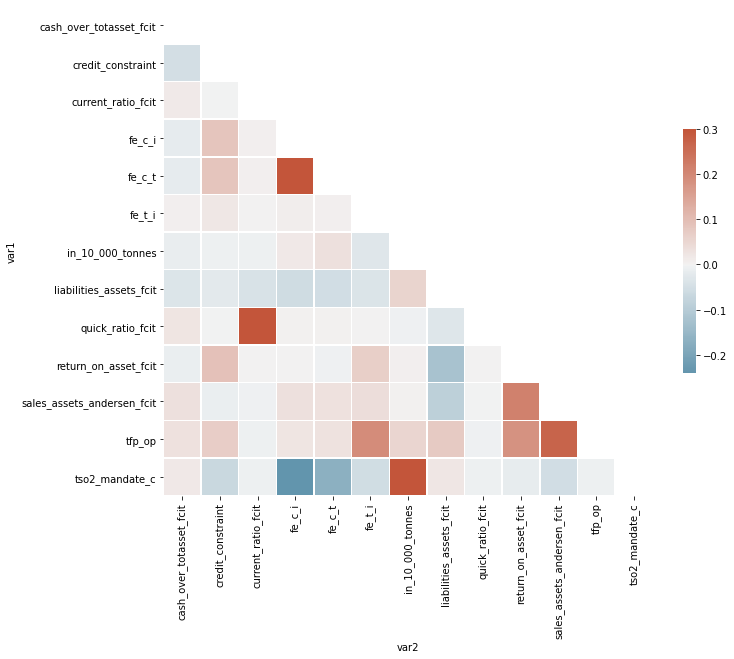

## Scatterplot

From the correlation plot above, pick up a $y$ variables.

We only plot the variables that succeed the Anova test, minus the $y$ var.

Besides, to avoid loading all the table, we have implemented the following rule:

if the size of the table is above >150K rows, then we randomly load 150K rows

First of all, you need to define the Y-axis variables

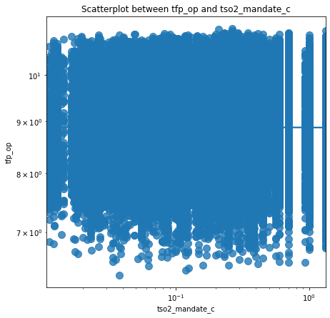

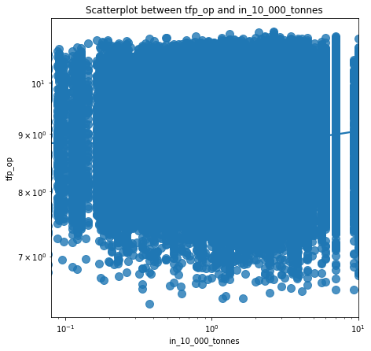

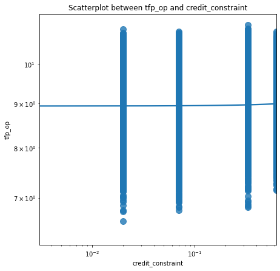

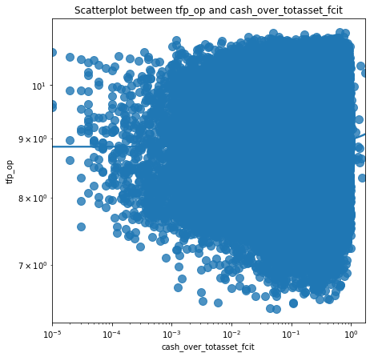

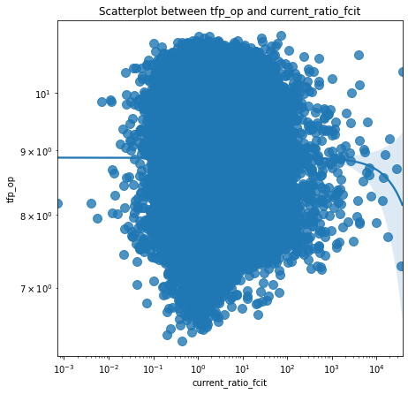

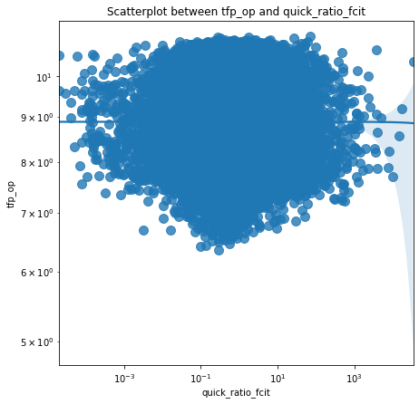

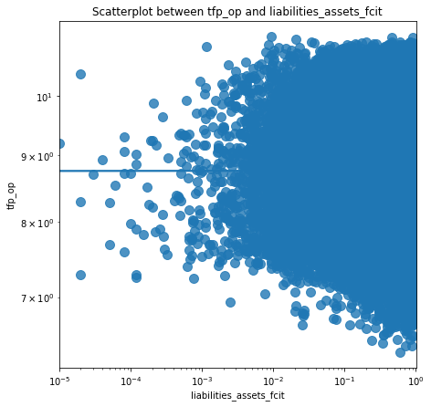

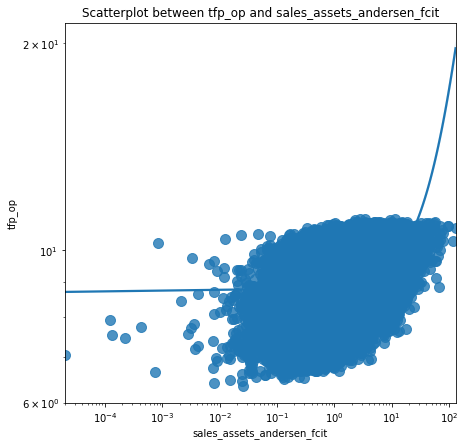

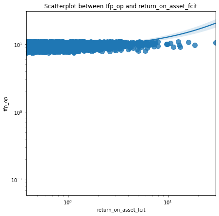

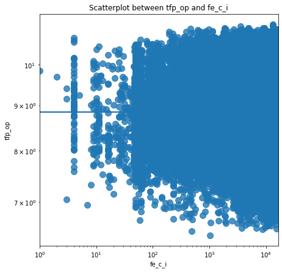

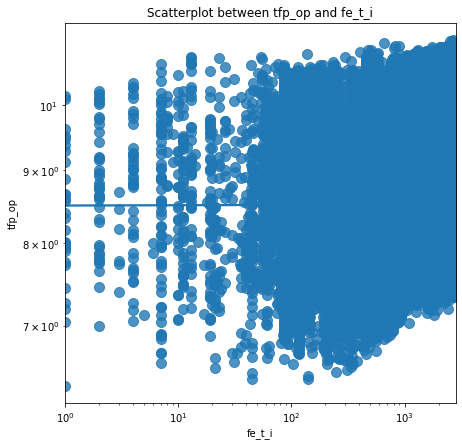

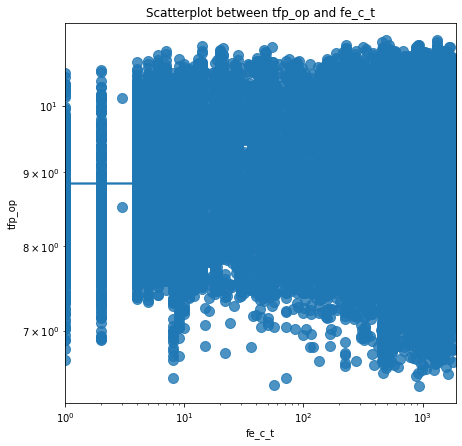

### Diverging bars

The diverging bar plot is plotting for the variables to succeed the Anova test

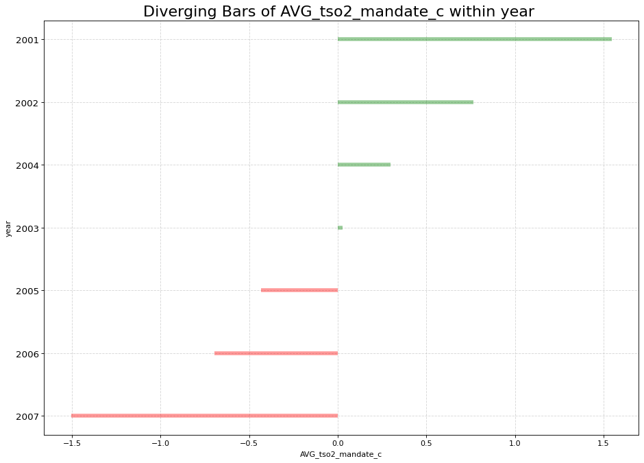

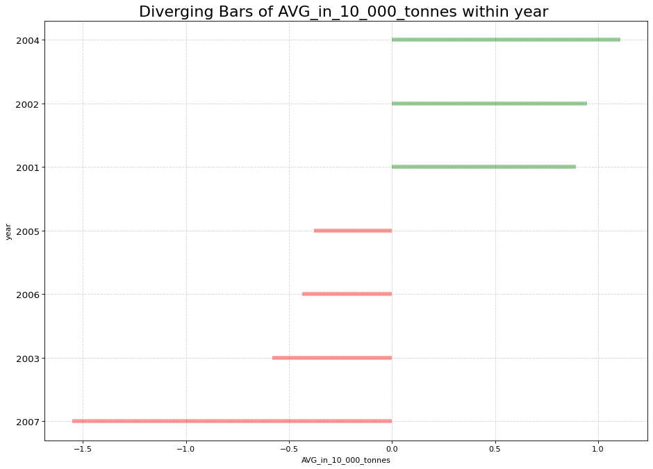

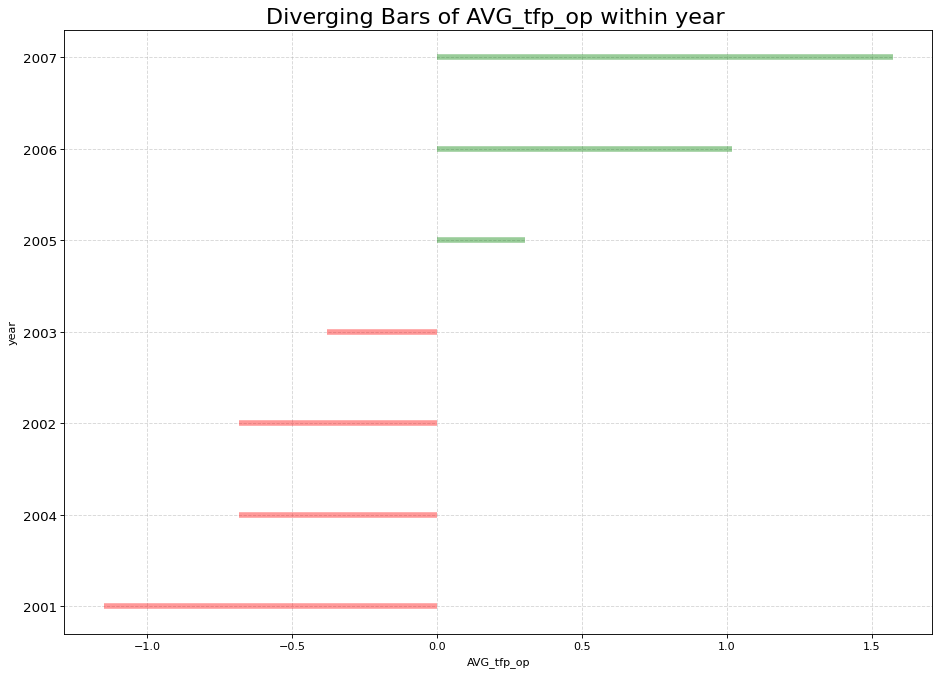

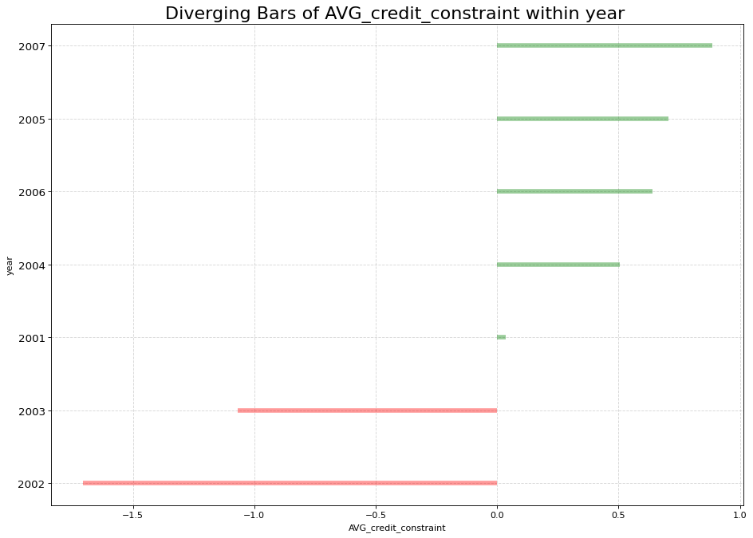

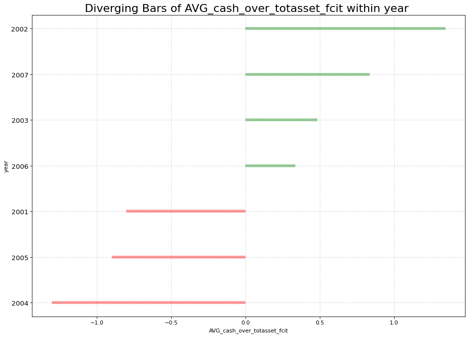

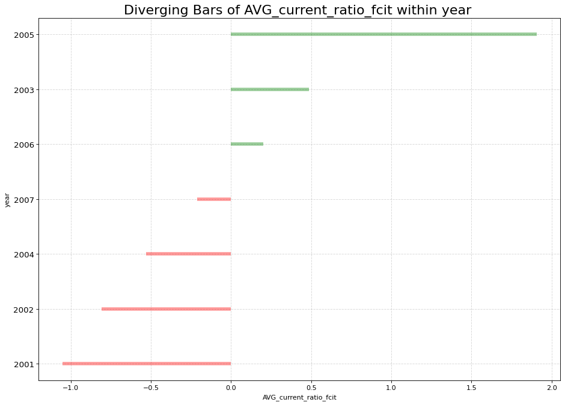

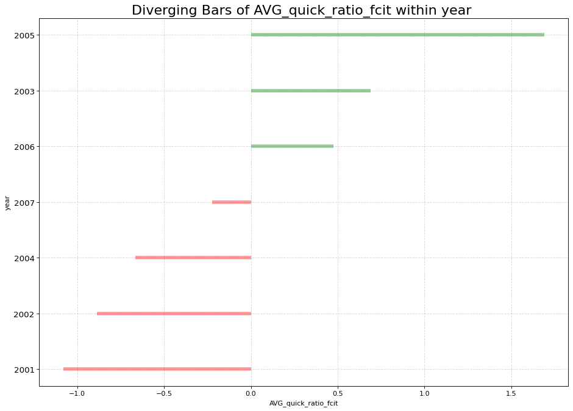

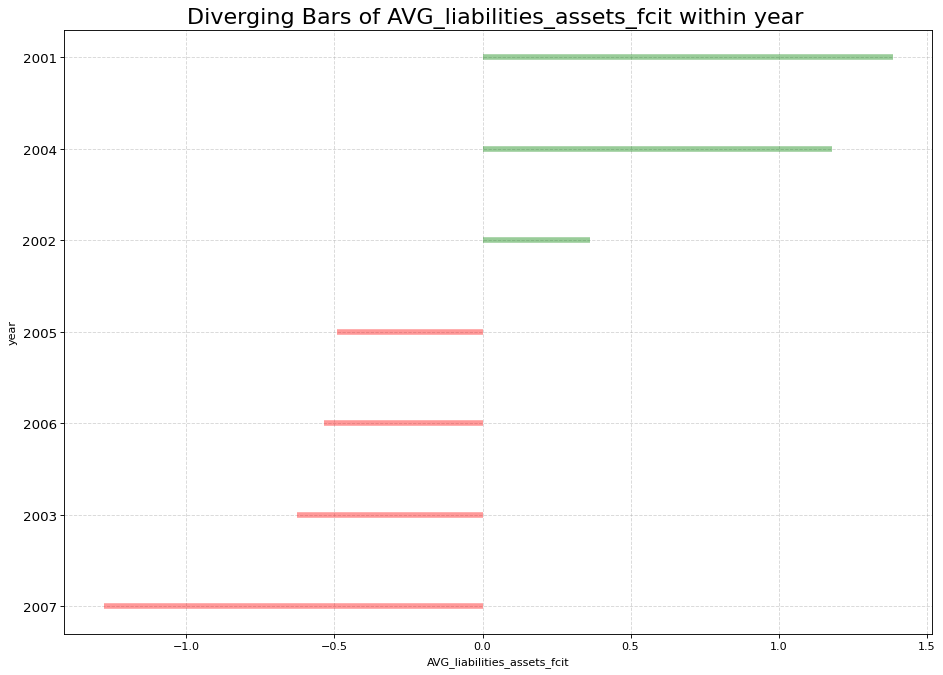

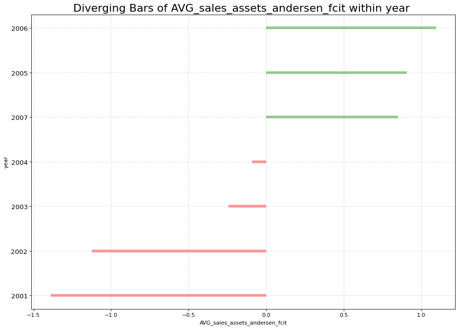

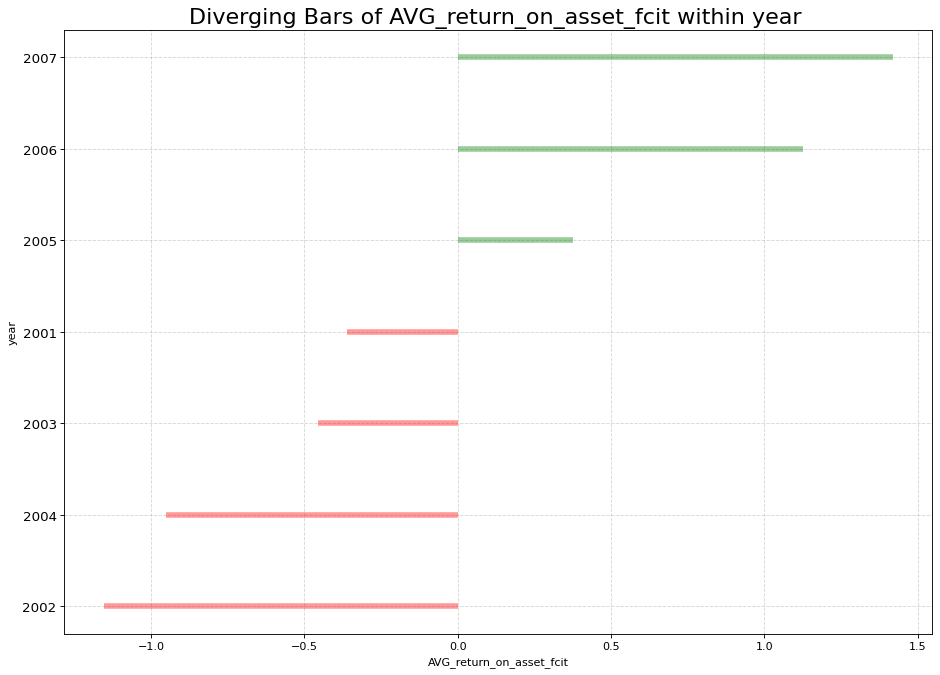

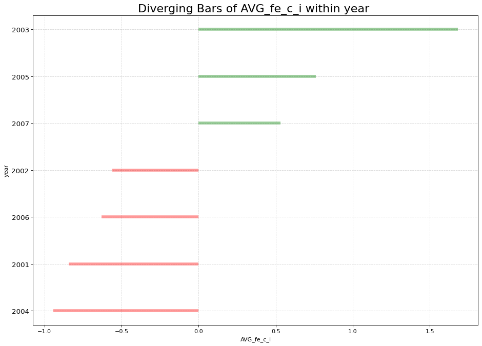

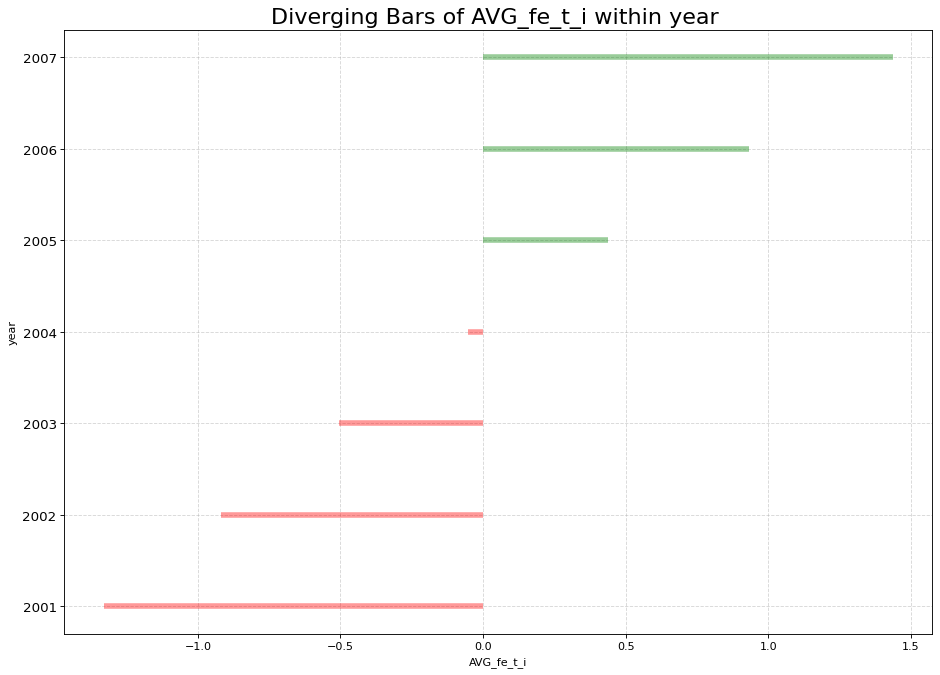

[1 more figures not shown]